# TempOrder_Exp1a_Analysis

Yining Ding

2025-02-18

Dataset: 74 SONA participants collected in 2023/04. 34 were excluded, totaling 40 used in the actual analysis.

```r
# Basic
library(psych)
library(tidyverse)
library(dplyr)
# Analysis
library(lme4)
library(lmerTest)
library(performance)
library(jtools)
library(optimx)
library(lsr)
library(emmeans)
library(car)
library(brglm2)
library(plotrix) # calculating SE
library(qdap) # count_syllable
# Plotting
library(ggplot2)
library(lattice)
library(sjPlot)
library(ggpubr)
library(DHARMa)
library(ggsignif)
# Disable scientific notation
options(scipen=999)
```

```r
# GLMER Optimizers
cl1 <- glmerControl(optimizer = "bobyqa", calc.derivs = FALSE, optCtrl = list(maxfun = 1e+09), check.conv.grad = .makeCC("warning",
tol = 0.002, relTol = NULL), check.conv.singular = .makeCC(action = "message", tol = 1e-09), check.conv.hess = .makeCC(action = "warning", tol = 0.000001))
cl2 <- glmerControl(optimizer = "Nelder_Mead", calc.derivs = FALSE, optCtrl = list(maxfun = 1e+09), check.conv.grad = .makeCC("warning", tol = 0.002, relTol = NULL), check.conv.singular = .makeCC(action = "message", tol = 1e-09), check.conv.hess = .makeCC(action = "warning", tol = 0.000001))
cl3 <- glmerControl(optimizer = "optimx", calc.derivs = FALSE, optCtrl = list(method = "nlminb", maxiter = 1e+09), check.conv.grad = .makeCC("warning", tol = 0.002, relTol = NULL), check.conv.singular = .makeCC(action = "message", tol = 1e-09), check.conv.hess = .makeCC(action = "warning", tol = 0.000001))
cl4 <- glmerControl(optimizer = "nloptwrap", calc.derivs = FALSE, optCtrl = list(maxfun = 1e+09), check.conv.grad = .makeCC("warning", tol = 0.002, relTol = NULL), check.conv.singular = .makeCC(action = "message",
tol = 1e-09), check.conv.hess = .makeCC(action = "warning",
tol = 0.000001))

# LMER Optimizers
cl_a <- lmerControl(optimizer = "bobyqa", optCtrl = list(maxfun = 1e+09))
cl_b <- lmerControl(optimizer = "Nelder_Mead", optCtrl = list(maxfun = 1e+09))
cl_c <- lmerControl(optimizer = "optimx", optCtrl = list(method = "nlminb",
    maxiter = 1e+09))
cl_d <- lmerControl(optimizer = "nloptwrap", optCtrl = list(maxfun = 1e+09))
```

# 1. Data Prep

## 1.1 Import data files

```r
# set the path of the folder containing CSV files
folder_path <- "/Users/dcl/Library/CloudStorage/Box-Box/DCL_ARCHIVE/Documents/Events/exp165_TemporalOrder/Manuscript/Complete_Data/Data_Deidentification/Data_Exp1a"

# get the list of CSV files in the folder
csv_files <- list.files(folder_path, pattern = "*.csv")

# initialize an empty list to store dataframes
df_list <- list()

# loop through the list of CSV files, reading each file into a dataframe and adding it to the list
for (csv_file in csv_files) {
  df <- read.csv(file.path(folder_path, csv_file))
  df_list[[csv_file]] <- df
}

# combine all dataframes in the list into a single dataframe
combined_df <- do.call(rbind, df_list)
```

```r
# Select Demographic Information
demographics_combined_df <- combined_df %>% filter(task == "demographics") %>%
  dplyr::select('run_id', 'response')
```

```r
# Helper Function 1: Extract Age
extract_text_between_age_and_gender <- function(text) {
  pattern <- "(?<=\\bage\\b)(.*?)(?=\\bgender\\b)"
  matches <- regmatches(text, gregexpr(pattern, text, perl = TRUE))
  unlist(matches)
}
# Helper Function 2: Extract Gender
extract_text_between_gender_and_race <- function(text) {
  pattern <- "(?<=\\bgender\\b)(.*?)(?=\\brace\\b)"
  matches <- regmatches(text, gregexpr(pattern, text, perl = TRUE))
  unlist(matches)
}
# Helper Function 3: Eliminate Text
eliminate_text <- function(text){
  gsub("\\D", "", text)
}
# Helper Function 4: Eliminate Symbols
eliminate_symbols <- function(text){
  gsub("[[:punct:]]", "", text)
}

# Helper Function 5: Count "Yes"
count_yes <- function(input_string) {
  matches <- gregexpr("Yes", input_string, ignore.case = TRUE)
  match_count <- sum(sapply(matches, function(x) if (x[1] == -1) 0 else length(x)))
  return(match_count)
}

# Helper Function 6: Extract Race
extract_text_between_race_and_hispLat <- function(text) {
  pattern <- "(?<=\\brace\\b)(.*?)(?=\\bhispanicLatino\\b)"
  matches <- regmatches(text, gregexpr(pattern, text, perl = TRUE))
  unlist(matches)
}

# Helper Function 7: Extract Education_years
extract_education_years <- function(text) {
  return(substr(text, 21, 22))
}

# Helper Function 8: Extract HispanicLatino
extract_hispLat <- function(text) {
  string_length <- nchar(text)
  return(substr(text, string_length - 5, string_length - 1))
}
```

```r
# Get Age Information
demographics_combined_df$age_raw <- apply(demographics_combined_df[, "response", drop = FALSE], 1, extract_text_between_age_and_gender)
demographics_combined_df$age <- apply(demographics_combined_df[, "age_raw", drop = FALSE], 1, eliminate_text)
demographics_combined_df$age <- as.numeric(demographics_combined_df$age)

# Get Gender Information
demographics_combined_df$gender_raw <- apply(demographics_combined_df[, "response", drop = FALSE], 1, extract_text_between_gender_and_race)
demographics_combined_df$gender <- apply(demographics_combined_df[, "gender_raw", drop = FALSE], 1, eliminate_symbols)

# Get Race Information
demographics_combined_df$race_raw <- apply(demographics_combined_df[, "response", drop = FALSE], 1, extract_text_between_race_and_hispLat)
demographics_combined_df$race <- apply(demographics_combined_df[, "race_raw", drop = FALSE], 1, eliminate_symbols)

# Get Education_years Information
demographics_combined_df$edu_years <- apply(demographics_combined_df[, "response", drop = FALSE], 1, extract_education_years)

# Get Hispanic/Latino Information
demographics_combined_df$hispLat_raw <- apply(demographics_combined_df[, "response", drop = FALSE], 1, extract_hispLat)
demographics_combined_df$hispLat <- apply(demographics_combined_df[, "hispLat_raw", drop = FALSE], 1, eliminate_symbols)
```

```r
# Select only useful columns
demographics_df <- demographics_combined_df %>%
  dplyr::select('run_id', 'age', 'gender', 'race', 'edu_years', 'hispLat')
```

```r
# Get Gender Distribution
gender_df <- as.data.frame(table(demographics_df$gender))
gender_df <- gender_df %>% rename(Gender = Var1,
                                  Number = Freq)
gender_df$percentage <- gender_df$Number / nrow(demographics_df)
gender_df
```

| Gender | Number | percentage |
| --- | --- | --- |
| Female | 52 | 0.70270270 |
| Intersex nonbinary or other | 1 | 0.01351351 |
| Male | 21 | 0.28378378 |

```r
# Get Race Distribution
race_df <- as.data.frame(table(demographics_df$race))
race_df <- race_df %>% rename(Race = Var1,
                              Number = Freq)
race_df$percentage <- race_df$Number / nrow(demographics_df)
race_df
```

| Race | Number | percentage |
| --- | --- | --- |
| American IndianAlaskan NativeWhite | 1 | 0.01351351 |
| Asian | 24 | 0.32432432 |
| AsianNative Hawaiian or Other Pacific Islander | 1 | 0.01351351 |
| AsianWhite | 3 | 0.04054054 |
| Black or African American | 10 | 0.13513514 |
| White | 34 | 0.45945946 |
| WhiteAsian | 1 | 0.01351351 |

```r
# Get Hispanic/Latino Distribution
hispLat_df <- as.data.frame(table(demographics_df$hispLat))
hispLat_df <- hispLat_df %>% rename(HispanicLatino = Var1,
                                    Number = Freq)
hispLat_df$percentage <- hispLat_df$Number / nrow(demographics_df)
hispLat_df
```

| HispanicLatino | Number | percentage |
| --- | --- | --- |
| No | 68 | 0.91891892 |
| Yes | 6 | 0.08108108 |

```r
# Fix typo in responses
edu_years_info <- demographics_df %>% dplyr::select('run_id', 'edu_years')
edu_years_info <- edu_years_info %>%
  mutate(edu_years = case_when(
    edu_years == "1." ~ "13",
    edu_years == "2" ~ "14",
    edu_years == "2\"" ~ "14",
    edu_years == "3\"" ~ "15",
    edu_years == "4\"" ~ "16",
    TRUE ~ edu_years  # Keeps other values unchanged
  ))
```

```r
# Get Education Years Distribution
# edu_years_info
edu_years_df <- as.data.frame(table(edu_years_info$edu_years))
edu_years_df <- edu_years_df %>% rename(Education_Years = Var1,
                                        Number = Freq)
mean(as.numeric(edu_years_info$edu_years))
```

```
## [1] 14.33784
```

```r
sd(as.numeric(edu_years_info$edu_years))
```

```
## [1] 2.049237
```

```r
# Get Age Distribution
mean(demographics_combined_df$age)
```

```
## [1] 20.12162
```

```r
sd(demographics_combined_df$age)
```

```
## [1] 1.146199
```

```r
nrow(demographics_combined_df)
```

```
## [1] 74
```

```r
min(demographics_combined_df$age)
```

```
## [1] 18
```

```r
max(demographics_combined_df$age)
```

```
## [1] 23
```

```r
# Time elapsed when the test phase of the 1st story started
time_at_1st_test <- combined_df %>% subset(trial_index == 118)
# Time elapsed when the encoding phase of the 1st story started
time_at_1st_story <- combined_df %>% subset(trial_index == 59)

# Record each participant's delay time (for distraction task)
time_diff <- as.data.frame(time_at_1st_test$time_elapsed - time_at_1st_story$time_elapsed)
time_diff <- as.data.frame(cbind(time_at_1st_test$run_id, time_diff$`time_at_1st_test$time_elapsed - time_at_1st_story$time_elapsed`))
# convert delay time to minutes
time_diff$diff <- time_diff$V2 / 1000 / 60
#time_diff %>% arrange(desc(diff))
mean(time_diff$diff)
```

```
## [1] 2.220574
```

```r
sd(time_diff$diff)
```

```
## [1] 0.7719621
```

## 1.2 Clean data

```r
# select useful columns
complete_data <- combined_df %>%
  dplyr::select('run_id', 'rt', 'time_elapsed', 'response', 'trial_index', 'trial_type', 'task', 'stimuli_type', 'stimuli_name', 'total_count', 'coarse_count', 'fine_within_count', 'event_sentence', 'pair_num', 'pair_location', 'pair_first','pair_second', 'pair_type', 'curr_first', 'curr_second', 'normal0_shuffle1', 'correct_answer', 'correct')
```

## 2. Data Exclusion

### 2.1 Removing individual participants

Criteria 1: Exclude - Subjects who reported technical problems (Excluded = 2)

```r
# complete_data %>%
#  filter(task == 'ending_questions') %>%
#  dplyr::select(run_id, response)
```

```r
# Store problematic IDs for Criteria 1 (reported technical problems)
exclusion_c1_list <- c(112, 84)
```

Criteria 2: Exclude - Subjects whose reaction time > 40000 ms for more than 5 individual trials or < 300 ms for more than 5 individual trials that require meaningful responses

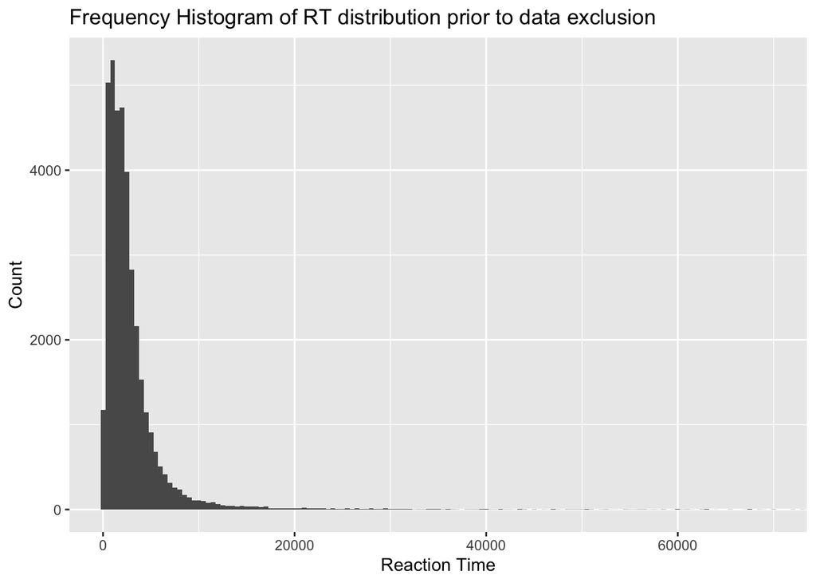

```r
# Frequency Histogram of RT distribution prior to data exclusion
complete_data$rt <- as.numeric(complete_data$rt)
complete_data %>%
  filter(task == 'encoding_sentence' | task == 'TOM' | task == 'TOM_Conf' | task == 'Distance') %>%
  ggplot(aes(x=rt)) +
    geom_histogram(binwidth = 500) +
    coord_cartesian(xlim = c(0, 70000)) +
    labs(title = "Frequency Histogram of RT distribution prior to data exclusion", x = "Reaction Time", y = "Count")
```

```r
# Filter out problematic IDs (problematic: rt > 40000 ms for > 5 trials, or < 300 ms for > 5 trials)
trial_too_long <- complete_data %>% filter(task == 'encoding_sentence'| task == 'TOM' | task == 'TOM_Conf' | task == 'Distance') %>% filter(rt > 40000) %>% group_by(run_id) %>% summarize(num_trial_too_long = sum(rt > 40000)) %>% filter(num_trial_too_long > 5)
# trial_too_long
trial_too_short <- complete_data %>% filter(task == 'encoding_sentence' | task == 'TOM' | task == 'TOM_Conf' | task == 'Distance') %>% filter(rt < 300) %>% group_by(run_id) %>% summarize(num_trial_too_short = sum(rt < 300)) %>% filter(num_trial_too_short > 5)
# trial_too_short

# Store problematic IDs for Criteria 2.1 (rt > 40000 ms for > 5 trials)
exclusion_c2.1_list <- trial_too_long$run_id

# Store problematic IDs for Criteria 2.2 (rt < 300 ms for > 5 trials)
exclusion_c2.2_list <- trial_too_short$run_id
```

```r
length(unique(exclusion_c2.2_list, exclusion_c2.1_list))
```

```
## [1] 26
```

Criteria 3: Exclude subjects whose mean accuracy for Math Questions < 75%

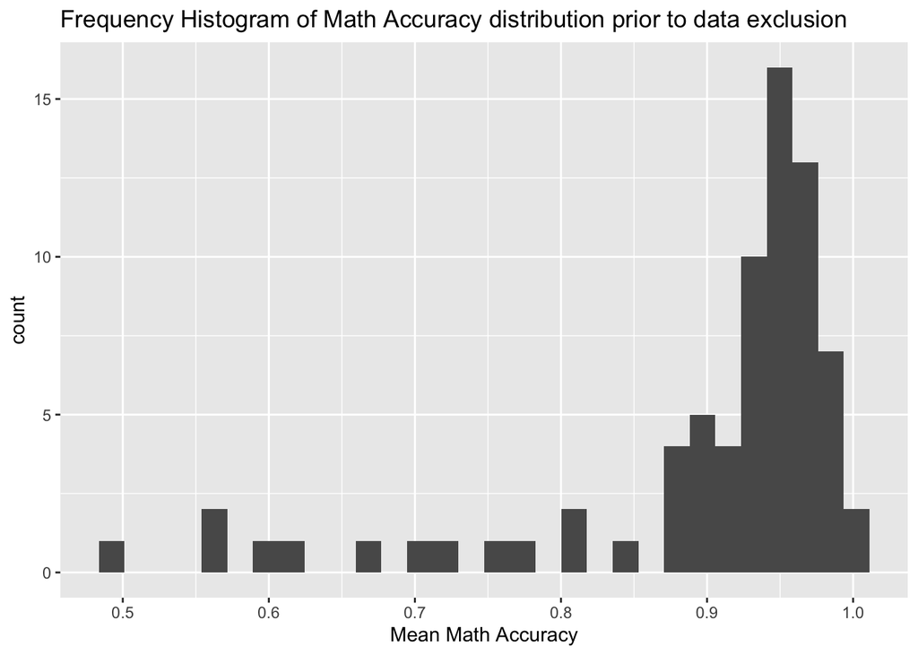

```r
## Math_data: filter out only math data
Math_data <- complete_data %>%
  filter(task == 'math')

# Factorization & Score math problems
Math_data$math_correct_resp <- tolower(Math_data$correct)
Math_data$math_correct <- ifelse(Math_data$math_correct_resp == "true", 1, 0)

# Frequency Histogram of Math Accuracy distribution prior to data exclusion
Math_data_mean_bySub <- Math_data %>%
  group_by(run_id) %>%
  summarize(meanMath = mean(math_correct))
Math_data_mean_bySub %>%
  ggplot(aes(x=meanMath)) +
    geom_histogram() +
  labs(title = "Frequency Histogram of Math Accuracy distribution prior to data exclusion", x = "Mean Math Accuracy", y = "count")
```

```r
# Filter out subjects that have < 75% mean accuracy for math questions
Math_too_low <- Math_data_mean_bySub %>% filter(meanMath < 0.75)

# Store problematic IDs for Criteria 3 (Mean Math Accuracy < 75%)
exclusion_c3_list <- Math_too_low$run_id
```

Criteria 4: Exclude - Subjects whose Temporal Order Memory Mean Accuracy is below 3SD from group mean

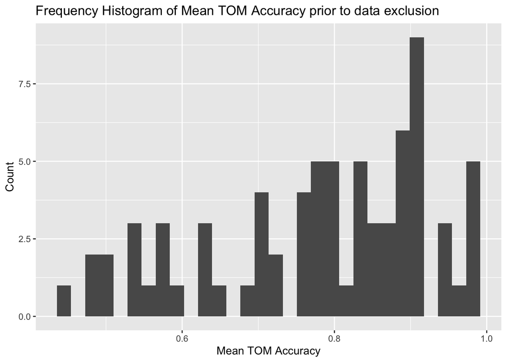

```r
## TOM_raw_data: only TOM data
TOM_raw_data <- complete_data %>%
  filter(task == 'TOM')

# Scoring: compare response with correct answer to get TOM_result (0/1)
TOM_raw_data$TOM_response <- as.numeric(TOM_raw_data$response)
TOM_raw_data$TOM_result <- as.numeric(TOM_raw_data$response == TOM_raw_data$correct_answer)

# Determine upper and lower limit (+/-3SD)
low_CI_TOM <-  mean(TOM_raw_data$TOM_result) - 3 * sd(TOM_raw_data$TOM_result)

# Calculate TOM accuracy
TOM_raw_data_bySub <- TOM_raw_data %>% group_by(run_id) %>% summarize(meanTOM = mean(TOM_result))
TOM_raw_data_bySub <- ungroup(TOM_raw_data_bySub)
TOM_raw_data_bySub <- as.data.frame(TOM_raw_data_bySub)

# Frequency Histogram of mean TOM accuracy prior to data exclusion
TOM_raw_data_bySub %>% ggplot(aes(x=meanTOM)) +
    geom_histogram() +
  labs(title = "Frequency Histogram of Mean TOM Accuracy prior to data exclusion", x = "Mean TOM Accuracy", y = "Count")
```

```r
# Lower Limit: Exclude no one
trial_TOM_too_low <- TOM_raw_data_bySub %>% filter(meanTOM < low_CI_TOM)

# Store problematic IDs for Criteria 4 (Mean TOM Accuracy < 3SD below group mean)
exclusion_c4_list <- trial_TOM_too_low$run_id
```

Data Exclusion Decision:

```r
# Decision: Merge ID lists from Criteria 1-4
exclusion_complete_list <- unique(c(exclusion_c1_list, exclusion_c2.1_list, exclusion_c2.2_list, exclusion_c3_list, exclusion_c4_list))
# exclusion_complete_list # Print out IDs to be removed

# In "complete_data" dataframe, tag all the trials that are excluded based on subject exclusion criteria
complete_data$excluded_by_subject <- ifelse(complete_data$run_id %in% exclusion_complete_list, yes = "TRUE", no = "FALSE")

# Create "main_data" dataframe: Exclude problematic subjects, and filter to only include trials that are relevant in the analysis
main_data <- complete_data[!(complete_data$run_id %in% exclusion_complete_list), ] %>% filter(task == 'encoding_sentence' | task == 'TOM' | task == 'TOM_Conf' | task == 'Distance')
main_data$stimuli_type <- ifelse(test = main_data$stimuli_type == "HC", yes = "CS", no = "FS") # For stimuli_type, Change all "HC" to "CS" and all "LC" to "FS" to avoid confusion in condition naming

# Sample Size after data exclusion
nSample <- length(unique(main_data$run_id))
nSample # Print out sample size after removal
```

```
## [1] 40
```

```r
# id_list after data exclusion
id_list <- unique(main_data$run_id)
```

### 2.2 Excluding individual trials

#### 2.2.1 Encoding Trials

Criterion: Exclude all encoding trials that have reaction time < 300 ms, or > 3SD above the mean reaction time of sentences that are not the opening (first) or the concluding (last) sentences of each narrative.

```r
# Create "encoding_rt_raw" dataframe for encoding trials
raw_encoding_rt <- main_data %>% filter(task == "encoding_sentence") %>% dplyr::select(-c('pair_num', 'pair_location', 'pair_first','pair_second', 'pair_type', 'curr_first', 'curr_second', 'normal0_shuffle1', 'correct_answer', 'correct'))

# Tag all the trials that are excluded by being opening and ending sentences in each narrative
raw_encoding_rt$excluded_by_loc <- ifelse(raw_encoding_rt$fine_within_count == 0 | raw_encoding_rt$fine_within_count == 99 | raw_encoding_rt$total_count == 0 | raw_encoding_rt$total_count == 99, yes = TRUE, no = FALSE)

# Calculate encoding_rt upper limit: 3SD above mean (excluding opening and ending sentences)
encoding_rt_upperLim <- as.numeric(raw_encoding_rt %>% filter(excluded_by_loc == FALSE) %>% summarize(upperLim = mean(rt) + 3 * sd(rt)))
encoding_rt_upperLim # Print out encoding_rt upper limit: 210031 ms
```

```
## [1] 210031.3
```

```r
# Tag all the trials that are excluded by rt < 300 or > 3SD above mean
raw_encoding_rt$excluded_by_rt <- ifelse(raw_encoding_rt$rt > encoding_rt_upperLim | raw_encoding_rt$rt < 300, yes = TRUE, no = FALSE)
mean(raw_encoding_rt$excluded_by_rt == TRUE) # Print out the proportion of encoding trials being excluded based on rt criterion
```

```
## [1] 0.001944444
```

```r
# Create "encoding_rt_main" dataframe: Assign fine / coarse sentence location before filtering out problematic trials
encoding_rt_main <- raw_encoding_rt %>% filter(excluded_by_loc == FALSE)
encoding_rt_main$fine_loc <- rep(c(1, 2, 3, 4, 5), nrow(encoding_rt_main)/5) # Assign fine-level location to each sentence trial
encoding_rt_main$coarse_loc <- rep(rep(1:5, each = 5), times = nrow(encoding_rt_main)/25) # Assign coarse-level event membership to each sentence trial
encoding_rt_main$sentence_index <- rep(rep(1:25, each = 1), times = nrow(encoding_rt_main)/25) # NEW: Assign sentence index to each sentence trial

encoding_rt_main$fine_loc_type <- ifelse(test = encoding_rt_main$fine_loc == 1, yes = "Boundary", no = "Non-boundary")
encoding_rt_main$coarse_loc_type <- ifelse(test = encoding_rt_main$coarse_loc == 1, yes = "First Coarse Event", no = "Other Event")

# Create "encoding_rt_data" dataframe: Filter out problematic trials
encoding_rt_data <- encoding_rt_main %>% filter(excluded_by_rt == FALSE)
encoding_rt_data$logRT <- log(encoding_rt_data$rt)

# as.factor() certain trials
encoding_rt_data <- mutate(encoding_rt_data, stimuli_type = as.factor(stimuli_type), stimuli_name = as.factor(stimuli_name), fine_loc_type = as.factor(fine_loc_type), coarse_loc_type = as.factor(coarse_loc_type), run_id = as.factor(run_id))
```

#### 2.2.2 Recency Judgment (aka Temporal Order Memory) Trials

Criterion: Exclude TOM trials that has RT < 300 ms or > 3SD above mean RT of all TOM trials.

```r
# Create "TempOrder_data" dataframe that includes TOM, TOM Confidence, and Temporal Distance Data for the same event pairs
TempOrder_data <- main_data %>% filter(task == "TOM") %>% dplyr::select(-c(total_count, coarse_count, fine_within_count, event_sentence, correct, excluded_by_subject))

TempOrder_data$TOM_response <- as.numeric(TempOrder_data$response)
TempOrder_data$TOM_result <- as.numeric(TempOrder_data$response == TempOrder_data$correct_answer) # Column TOM_result: Temporal Order Memory accuracy after scoring
TempOrder_data$TOM_rt <- TempOrder_data$rt # Column TOM_rt: Reaction Time for Temporal Order Memory

TD_data <- main_data %>% filter(task == "Distance")
TOM_Conf_data <- main_data %>% filter(task == "TOM_Conf")
TD_data$TD_rt <- TD_data$rt
TOM_Conf_data$TOM_Conf_rt <- TOM_Conf_data$rt

# Add TD and TOM_Conf data into TempOrder_data dataframe
TempOrder_data$TD <- TD_data$response # Column TD: Temporal Distance Rating
TempOrder_data$TOM_Conf <- TOM_Conf_data$response # Column TOM_Conf: Temporal Order Memory Confidence
TempOrder_data$TD_rt <- TD_data$TD_rt  # Column TD_rt: Reaction Time for Temporal Distance Rating
TempOrder_data$TOM_Conf_rt <- TOM_Conf_data$TOM_Conf_rt # Column TOM_Conf_rt: Reaction Time for Temporal Order Memory Confidence

# as.numeric certain columns
TempOrder_data <- mutate(TempOrder_data, TOM_rt = as.numeric(TOM_rt), TOM_Conf_rt= as.numeric(TOM_Conf_rt), TD_rt = as.numeric(TD_rt), TD = as.numeric(TD), TOM_Conf = as.numeric(TOM_Conf))

# create event_pair_type and each_pair column
TempOrder_data$event_pair_type <- paste(TempOrder_data$stimuli_type, TempOrder_data$pair_type, sep = "_")
TempOrder_data$each_pair <- paste(TempOrder_data$stimuli_name, TempOrder_data$pair_num, sep = "_")

# as.factor certain columns
TempOrder_data <- mutate(TempOrder_data, stimuli_type = as.factor(stimuli_type), stimuli_name = as.factor(stimuli_name), pair_type = as.factor(pair_type), event_pair_type = as.factor(event_pair_type), each_pair = as.factor(each_pair))

# Calculate TOM_rt upper limit: 3SD above mean
TOM_rt_upperLim <- as.numeric(TempOrder_data %>% summarize(upperLim = mean(TOM_rt) + 3 * sd(TOM_rt)))
TOM_rt_upperLim  # Print out TOM_rt upper limit: 22050 ms
```

```
## [1] 22050.2
```

```r
# Tag all the TOM trials that are excluded by rt < 300 or > 3SD above mean
TempOrder_data$excluded_by_TOMrt <- ifelse(TempOrder_data$TOM_rt > TOM_rt_upperLim | TempOrder_data$TOM_rt < 300, yes = TRUE, no = FALSE)
mean(TempOrder_data$excluded_by_TOMrt == TRUE) # Print out the proportion of TOM trials being excluded based on rt criterion
```

```
## [1] 0.0175
```

```r
# Create TOM_data dataframe that excluded problematic TOM trials
TOM_data <- TempOrder_data %>% filter(excluded_by_TOMrt == FALSE)
```

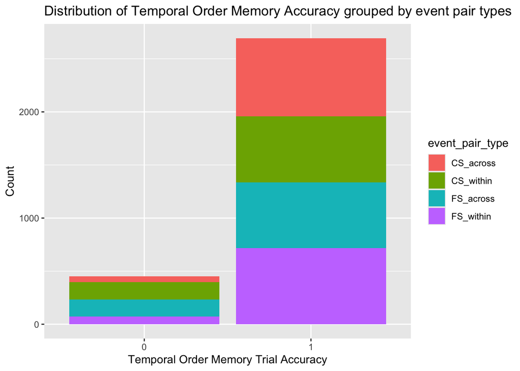

```r
# Graph the distribution of Temporal Order Memory Trial Accuracy across event_pair_types
TOM_data_dist <- ggplot(TOM_data, aes(x = as.factor(TOM_result), fill = event_pair_type)) +
  geom_bar() +
  labs(title = "Distribution of Temporal Order Memory Accuracy grouped by event pair types", x = "Temporal Order Memory Trial Accuracy", y = "Count")
TOM_data_dist
```

#### 2.2.3 Temporal Order Memory Confidence Trials

Criteria: (1) Exclude TOM Confidence trials that has RT < 300 ms or > 3SD above mean RT of all Confidence trials, and exclude (2) TOM Confidence trials that have its corresponding TOM trial being excluded in 2.2.2

```r
# Calculate TOM_Conf_rt upper limit: 3SD above mean
TOM_Conf_rt_upperLim <- as.numeric(TempOrder_data %>% summarize(upperLim = mean(TOM_Conf_rt) + 3 * sd(TOM_Conf_rt)))
TOM_Conf_rt_upperLim # Print out TOM_rt upper limit: 7491 ms
```

```
## [1] 7491.401
```

```r
# Tag all the TOM_Conf trials that are excluded by (1) rt < 300 or > 3SD above mean, or (2) when its corresponding TOM trial is excluded
TempOrder_data$excluded_by_TOM_Conf_rt <- ifelse(TempOrder_data$TOM_Conf_rt > TOM_Conf_rt_upperLim | TempOrder_data$TOM_Conf_rt < 300, yes = TRUE, no = FALSE)
mean(TempOrder_data$excluded_by_TOM_Conf_rt == TRUE) # Print out the proportion of TOM_Conf trials being excluded based on the criterion
```

```
## [1] 0.0128125
```

```r
# Create TOM_Conf_data dataframe that excluded problematic TOM trials and problematic TOM_Conf trials
TOM_Conf_data <- TempOrder_data %>% filter(excluded_by_TOMrt == FALSE & excluded_by_TOM_Conf_rt == FALSE)
```

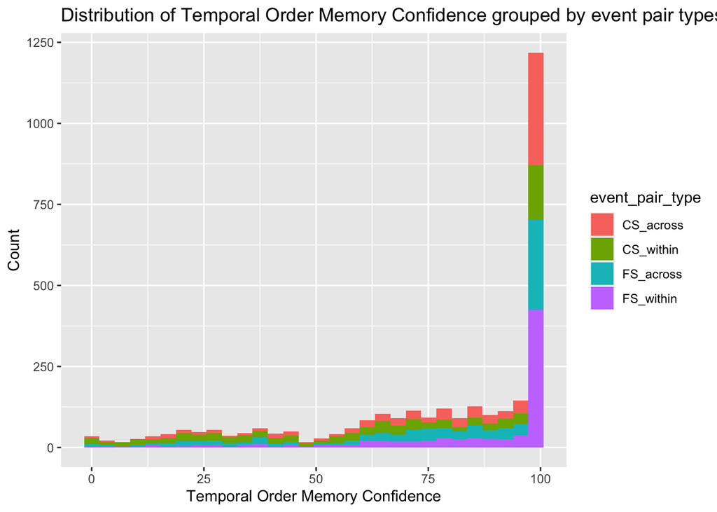

```r
# Graph the distribution of Temporal Order Memory Confidence across event_pair_types
TOM_Conf_data_dist <- ggplot(TOM_Conf_data, aes(x = TOM_Conf, fill = event_pair_type)) +
  geom_histogram() +
  labs(title = "Distribution of Temporal Order Memory Confidence grouped by event pair types", x = "Temporal Order Memory Confidence", y = "Count")
TOM_Conf_data_dist
```

```r
# Since 100 is the mode, we use 90 as the cutoff for converting TOM_Conf into a binary variable
# Binary TOM Confidence: "High Confidence" (Confidence > 90) vs. "Low Confidence" (Confidence < 90)
TOM_Conf_data$TOM_ConfGroup <- ifelse(test = TOM_Conf_data$TOM_Conf > 90, yes = "High Confidence", no = "Low Confidence")
TOM_Conf_data$TOM_resultGroup <- ifelse(test = TOM_Conf_data$TOM_result == 1, yes = "Correct", no = "Wrong")

# If use 90 as cutoff, 52% TOM trials are in low confidence group, 48% TOM trials are in high confidence group
mean(TOM_Conf_data$TOM_ConfGroup == "High Confidence")
```

```
## [1] 0.4750403
```

```r
mean(TOM_Conf_data$TOM_ConfGroup == "Low Confidence")
```

```
## [1] 0.5249597
```

```r
#TOM_Conf_data %>% ggplot(aes(x = TOM_ConfGroup, fill = TOM_resultGroup)) +
# geom_histogram(stat = "count", position = "dodge") +
#  facet_wrap(~event_pair_type) +
#  labs(title = "TOM Confidence Distribution in Different Conditions", x = "Confidence (High/Low)", y = "Count")
```

#### 2.2.3 Temporal Distance Rating Trials

Criteria: (1) Exclude Temporal Distance Rating trials that have RT < 300 ms or > 3SD above mean RT of all Temporal Distance Rating trials, and exclude (2) outlier trials that has extremely low frequency

```r
# Calculate TD_rt upper limit: 3SD above mean
TD_rt_upperLim <- as.numeric(TempOrder_data %>% summarize(upperLim = mean(TD_rt) + 3 * sd(TD_rt)))
TD_rt_upperLim # Print TD_rt upper limit: 17357 ms
```

```
## [1] 17357.3
```

```r
# Tag all the Temporal Distance trials that are excluded by rt < 300 or > 3SD above mean
TempOrder_data$excluded_by_TD_rt <- ifelse(TempOrder_data$TD_rt > TD_rt_upperLim | TempOrder_data$TD_rt < 300, yes = TRUE, no = FALSE)
mean(TempOrder_data$excluded_by_TD_rt == TRUE)
```

```
## [1] 0.0090625
```

```r
# Create TOM_Conf_data dataframe that excluded problematic TOM trials and problematic TOM_Conf trials
TD_data <- TempOrder_data %>% filter(excluded_by_TD_rt == FALSE)
```

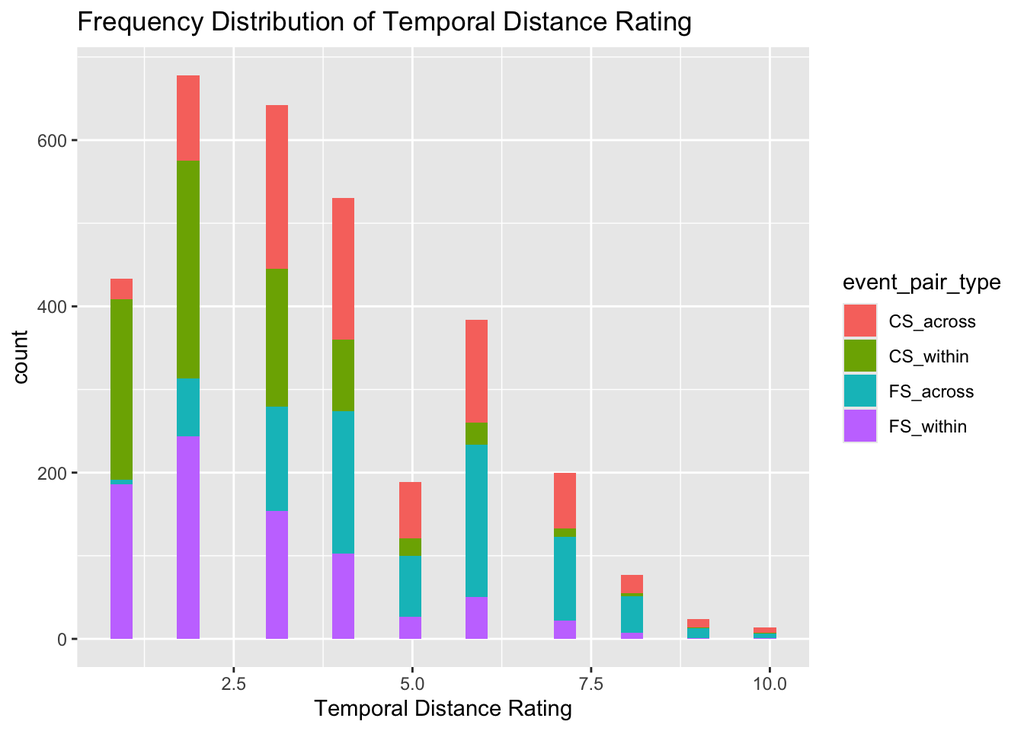

```r
# Graph the distribution of Temporal Distance Rating across different event_pair_types
TD_data_dist <- ggplot(TD_data, aes(x = TD, fill = event_pair_type)) +
  geom_histogram() +
  labs(title = "Frequency Distribution of Temporal Distance Rating", x = "Temporal Distance Rating")
TD_data_dist
```

# 2. Data Analysis of Encoding Time

Hypotheses:

```r
mean(encoding_rt_data$rt)
```

```
## [1] 2131.269
```

```r
std.error(encoding_rt_data$rt)
```

```
## [1] 39.9002
```

```r
sd(encoding_rt_data$rt)
```

```
## [1] 3986.427
```

```r
encoding_rt_raw_data_summ <- encoding_rt_data %>%
  group_by(coarse_loc_type, fine_loc_type) %>%
  summarize(meanRT = mean(rt),
            sdRT = sd(rt),
            num_obs = n())
encoding_rt_raw_data_summ
```

| coarse_loc_type | fine_loc_type | meanRT | sdRT | num_obs |
| --- | --- | --- | --- | --- |
| First Coarse Event | Boundary | 3347.789 | 6571.535 | 398 |
| First Coarse Event | Non-boundary | 2323.796 | 4184.148 | 1600 |
| Other Event | Boundary | 2282.566 | 2898.079 | 1598 |
| Other Event | Non-boundary | 1969.354 | 3941.834 | 6386 |

```r
# Apply contrast coding to RT data
encoding_rt_data_new <- encoding_rt_data
contrasts(encoding_rt_data_new$fine_loc_type) <- contr.sum(2)
contrasts(encoding_rt_data_new$coarse_loc_type) <- contr.sum(2)
contrasts(encoding_rt_data_new$stimuli_type) <- contr.sum(2)
```

```r
# Check contrast coding
contrasts(encoding_rt_data_new$fine_loc_type)
```

```
##              [,1]
## Boundary        1
## Non-boundary   -1
```

```r
contrasts(encoding_rt_data_new$coarse_loc_type)
```

```
##                    [,1]
## First Coarse Event    1
## Other Event          -1
```

```r
contrasts(encoding_rt_data_new$stimuli_type)
```

```
##    [,1]
## CS    1
## FS   -1
```

```r
# Add a column of counted syllables in each sentence (function from package "qdap")
encoding_rt_data_new$num_syllable <- syllable_sum(encoding_rt_data_new$event_sentence)
# Add a column indexing each sentence
encoding_rt_data_new$each_sentence <- paste(encoding_rt_data_new$stimuli_name, encoding_rt_data_new$fine_within_count, sep = "_")
```

```r
# Model 1: Random slope of fine_loc_type * coarse_loc_type by subject (does not converge), and random intercept of stimuli (Did not converge)
# encoding_logRT_maximal_model <- lmer(logRT ~ fine_loc_type * coarse_loc_type + stimuli_type + (fine_loc_type * coarse_loc_type #|run_id) + (1|stimuli_name), data = encoding_rt_data_new, control = cl_d)

# Model 2: Random slope of fine-level location type by subject, and random intercept of stimuli
encoding_logRT_SlopeFineLoc_model <- lmer(logRT ~ fine_loc_type * coarse_loc_type + stimuli_type + (fine_loc_type | run_id) + (1|stimuli_name), data = encoding_rt_data_new)

# Model 3: Random slopes of coarse_loc_type type by subject, and random intercept of stimuli
encoding_logRT_SlopeCoarseLoc_model <- lmer(logRT ~ fine_loc_type * coarse_loc_type + stimuli_type + (coarse_loc_type | run_id) + (1|stimuli_name), data = encoding_rt_data_new)

# Model 4: Random slopes of stimuli_type by subject, and random intercept of stimuli
encoding_logRT_SlopeStimuliType_model <- lmer(logRT ~ coarse_loc_type * fine_loc_type + stimuli_type + (stimuli_type | run_id) + (1|stimuli_name), data = encoding_rt_data_new)

# Model 5: Random intercepts of subject and stimuli
encoding_logRT_Intercept_model <- lmer(logRT ~ fine_loc_type * coarse_loc_type + stimuli_type + (1| run_id) + (1|stimuli_name), data = encoding_rt_data_new)

# Model Comparison favors Model 4
anova(encoding_logRT_Intercept_model, encoding_logRT_SlopeStimuliType_model, encoding_logRT_SlopeCoarseLoc_model, encoding_logRT_SlopeFineLoc_model)
```

|  | npar | AIC | BIC | logLik | deviance | Chisq | Df | Pr(>Chisq) |
| --- | --- | --- | --- | --- | --- | --- | --- | --- |
| encoding_logRT_Intercept_model | 8 | 18147.31 | 18204.98 | -9065.656 | 18131.31 | NA | NA | NA |
| encoding_logRT_SlopeStimuliType_model | 10 | 18046.37 | 18118.46 | -9013.186 | 18026.37 | 104.940986 | 2 | 0.00000000000000000000001630627 |
| encoding_logRT_SlopeCoarseLoc_model | 10 | 18140.46 | 18212.54 | -9060.228 | 18120.46 | 0.000000 | 0 | NA |
| encoding_logRT_SlopeFineLoc_model | 10 | 18136.81 | 18208.89 | -9058.404 | 18116.81 | 3.648813 | 0 | NA |

```r
# Select Model 4 as encoding_logRT_model:
encoding_logRT_model <- encoding_logRT_SlopeStimuliType_model
summ(encoding_logRT_model, digits = getOption("jtools-digits", 4))
```

```
## MODEL INFO:
## Observations: 9982
## Dependent Variable: logRT
## Type: Mixed effects linear regression
##
## MODEL FIT:
## AIC = 18078.8799, BIC = 18150.9653
## Pseudo-R² (fixed effects) = 0.0191
## Pseudo-R² (total) = 0.3034
##
## FIXED EFFECTS:
## ------------------------------------------------------------------------------
##                                           Est.     S.E.     t val.        d.f.
## ------------------------------------- -------- -------- ---------- -----------
## (Intercept)                             7.4395   0.0631   117.9508     47.3762
## coarse_loc_type1                        0.0994   0.0092    10.7834   9891.0387
## fine_loc_type1                          0.1148   0.0092    12.4557   9891.0071
## stimuli_type1                           0.0016   0.0293     0.0563     11.6201
## coarse_loc_type1:fine_loc_type1         0.0406   0.0092     4.4051   9891.0312
## ------------------------------------------------------------------------------
##
## ----------------------------------------------
##                                              p
## ------------------------------------- --------
## (Intercept)                             0.0000
## coarse_loc_type1                        0.0000
## fine_loc_type1                          0.0000
## stimuli_type1                           0.9561
## coarse_loc_type1:fine_loc_type1         0.0000
## ----------------------------------------------
##
## p values calculated using Satterthwaite d.f.
##
## RANDOM EFFECTS:
## ------------------------------------------
##     Group         Parameter     Std. Dev.
## -------------- --------------- -----------
##     run_id       (Intercept)     0.3589
##     run_id      stimuli_type1    0.0778
##  stimuli_name    (Intercept)     0.0820
##    Residual                      0.5890
## ------------------------------------------
##
## Grouping variables:
## ----------------------------------
##     Group       # groups    ICC
## -------------- ---------- --------
##     run_id         40      0.2670
##  stimuli_name      10      0.0139
## ----------------------------------
```

```r
# Report F value and p value from ANOVA!
anova(encoding_logRT_model, digits = getOption("jtools-digits", 4))
```

|  | Sum Sq | Mean Sq | NumDF | DenDF | F value | Pr(>F) |
| --- | --- | --- | --- | --- | --- | --- |
| coarse_loc_type | 40.338906289 | 40.338906289 | 1 | 9891.03867 | 116.281793303 | 0.00000000000000000000000000582176952875614 |
| fine_loc_type | 53.820451063 | 53.820451063 | 1 | 9891.00708 | 155.143982367 | 0.00000000000000000000000000000000002396516 |
| stimuli_type | 0.001097735 | 0.001097735 | 1 | 11.62013 | 0.003164353 | 0.95609624058691244918861684709554538130760 |
| coarse_loc_type:fine_loc_type | 6.731627580 | 6.731627580 | 1 | 9891.03120 | 19.404733515 | 0.00001068572902181340675146006824469679941 |

```r
emmean_RT_summ <- emmeans(encoding_logRT_model, specs = ~ fine_loc_type * coarse_loc_type)
summary(emmean_RT_summ, type = "response")
```

|  | fine_loc_type | coarse_loc_type | emmean | SE | df | asymp.LCL | asymp.UCL |
| --- | --- | --- | --- | --- | --- | --- | --- |
| 1 | Boundary | First Coarse Event | 7.694313 | 0.06902763 | Inf | 7.559021 | 7.829605 |
| 2 | Non-boundary | First Coarse Event | 7.383429 | 0.06410906 | Inf | 7.257777 | 7.509080 |
| 3 | Boundary | Other Event | 7.414262 | 0.06411119 | Inf | 7.288607 | 7.539918 |
| 4 | Non-boundary | Other Event | 7.265823 | 0.06282897 | Inf | 7.142680 | 7.388965 |

```r
# Planned Contrast for fine_loc_type, controlling for coarse_loc_type
encoding_logRT_pairwise <- emmeans(encoding_logRT_model, pairwise ~ fine_loc_type | coarse_loc_type)
encoding_logRT_pairwise
```

```
## $emmeans
## coarse_loc_type = First Coarse Event:
##  fine_loc_type emmean     SE  df asymp.LCL asymp.UCL
##  Boundary        7.69 0.0690 Inf      7.56      7.83
##  Non-boundary    7.38 0.0641 Inf      7.26      7.51
##
## coarse_loc_type = Other Event:
##  fine_loc_type emmean     SE  df asymp.LCL asymp.UCL
##  Boundary        7.41 0.0641 Inf      7.29      7.54
##  Non-boundary    7.27 0.0628 Inf      7.14      7.39
##
## Results are averaged over the levels of: stimuli_type
## Degrees-of-freedom method: asymptotic
## Confidence level used: 0.95
##
## $contrasts
## coarse_loc_type = First Coarse Event:
##  contrast                  estimate     SE  df z.ratio p.value
##  Boundary - (Non-boundary)    0.311 0.0330 Inf   9.423  <.0001
##
## coarse_loc_type = Other Event:
##  contrast                  estimate     SE  df z.ratio p.value
##  Boundary - (Non-boundary)    0.148 0.0165 Inf   9.010  <.0001
##
## Results are averaged over the levels of: stimuli_type
## Degrees-of-freedom method: asymptotic
```

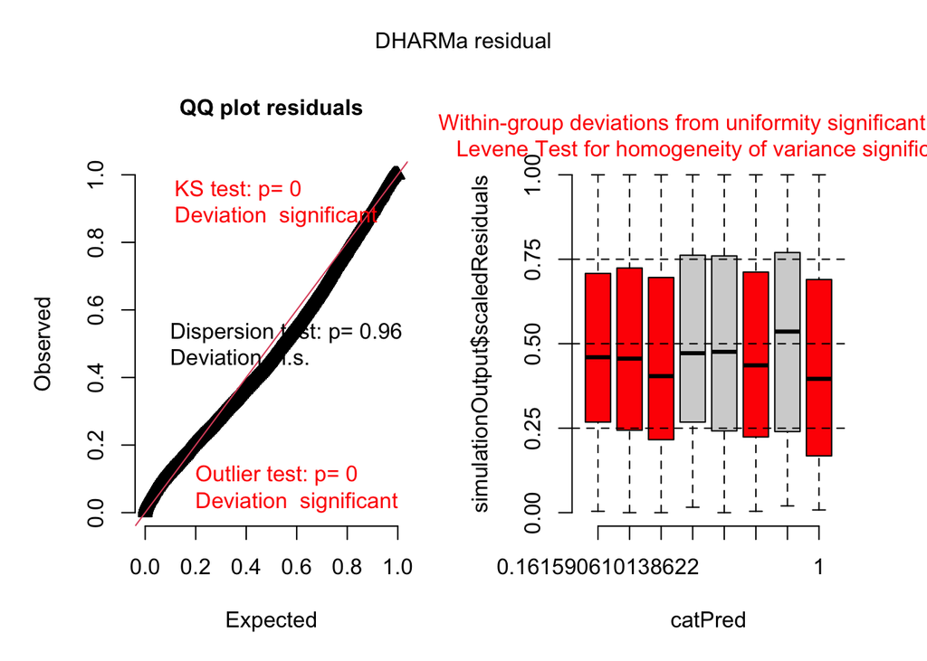

```r
# Check model fit
simulationOutput_RT <- simulateResiduals(fittedModel = encoding_logRT_model, plot = F)
plot(simulationOutput_RT)
```

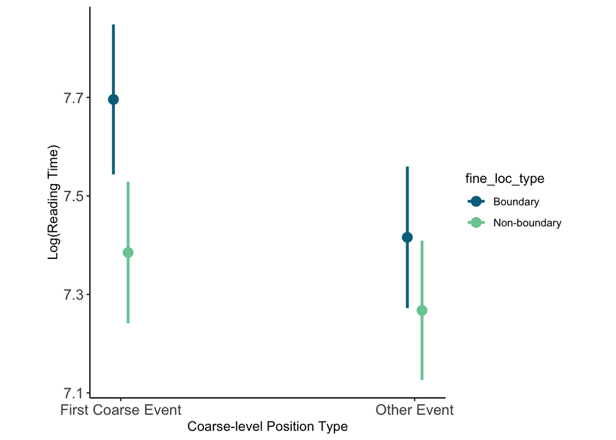

```r
plot_model(encoding_logRT_model, type = "int", terms = c("Coarse-level Position Type", "Fine-level Position Type"), colors = c("#00718B", "#7CCBA2"), dot.size = 3.5, line.size = 1.1) +
  theme_classic() +
  theme(aspect.ratio = 1.1, axis.text = element_text(size = 12)) +
  #aes(color=group) +
  #font_size(axis_title.x = 13, axis_title.y = 13,labels.x = 14, labels.y = 14) +
  labs(x = "Coarse-level Position Type", y = "Log(Reading Time)", title = NULL, size = 8)
```

### Supplemental: Fit a model that additionally controls for number of syllables in each sentence

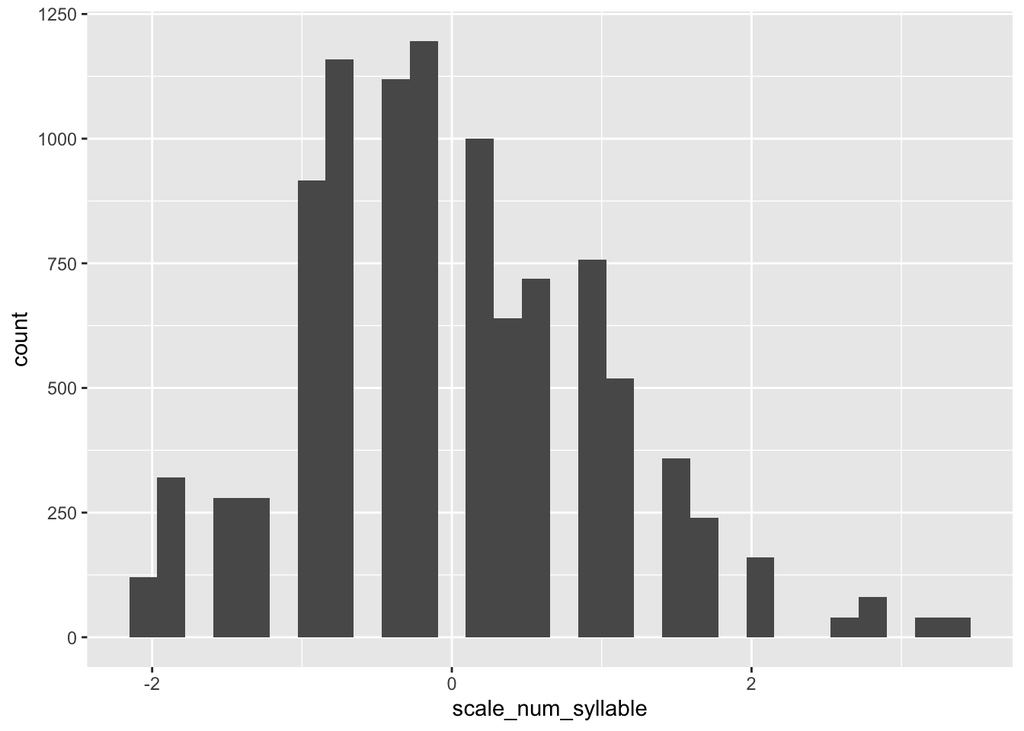

```r
encoding_rt_data_new$scale_num_syllable <- scale(encoding_rt_data_new$num_syllable)
encoding_rt_data_new %>% ggplot(aes(x = scale_num_syllable)) +
  geom_histogram()
```

```r
encoding_logRT_syllable_model <- lmer(logRT ~ coarse_loc_type * fine_loc_type + stimuli_type + scale_num_syllable + (stimuli_type + scale_num_syllable | run_id) + (1|stimuli_name), data = encoding_rt_data_new, control = cl_a)
summ(encoding_logRT_syllable_model, digits = getOption("jtools-digits", 4))
```

```
## MODEL INFO:
## Observations: 9982
## Dependent Variable: logRT
## Type: Mixed effects linear regression
##
## MODEL FIT:
## AIC = 17364.8545, BIC = 17465.7741
## Pseudo-R² (fixed effects) = 0.0718
## Pseudo-R² (total) = 0.3528
##
## FIXED EFFECTS:
## ------------------------------------------------------------------------------
##                                           Est.     S.E.     t val.        d.f.
## ------------------------------------- -------- -------- ---------- -----------
## (Intercept)                             7.4358   0.0589   126.2484     43.4345
## coarse_loc_type1                        0.0874   0.0089     9.8433   9852.2237
## fine_loc_type1                          0.1139   0.0089    12.8392   9851.1357
## stimuli_type1                           0.0527   0.0192     2.7464     22.9588
## scale_num_syllable                      0.1698   0.0105    16.0953     41.7596
## coarse_loc_type1:fine_loc_type1         0.0293   0.0089     3.3019   9852.1282
## ------------------------------------------------------------------------------
##
## ----------------------------------------------
##                                              p
## ------------------------------------- --------
## (Intercept)                             0.0000
## coarse_loc_type1                        0.0000
## fine_loc_type1                          0.0000
## stimuli_type1                           0.0115
## scale_num_syllable                      0.0000
## coarse_loc_type1:fine_loc_type1         0.0010
## ----------------------------------------------
##
## p values calculated using Satterthwaite d.f.
##
## RANDOM EFFECTS:
## -----------------------------------------------
##     Group           Parameter        Std. Dev.
## -------------- -------------------- -----------
##     run_id         (Intercept)        0.3592
##     run_id        stimuli_type1       0.0820
##     run_id      scale_num_syllable    0.0537
##  stimuli_name      (Intercept)        0.0405
##    Residual                           0.5667
## -----------------------------------------------
##
## Grouping variables:
## ----------------------------------
##     Group       # groups    ICC
## -------------- ---------- --------
##     run_id         40      0.2856
##  stimuli_name      10      0.0036
## ----------------------------------
```

```r
emmeans(encoding_logRT_syllable_model, pairwise ~ fine_loc_type | coarse_loc_type)
```

```
## $emmeans
## coarse_loc_type = First Coarse Event:
##  fine_loc_type emmean     SE  df asymp.LCL asymp.UCL
##  Boundary        7.67 0.0648 Inf      7.54      7.79
##  Non-boundary    7.38 0.0599 Inf      7.26      7.50
##
## coarse_loc_type = Other Event:
##  fine_loc_type emmean     SE  df asymp.LCL asymp.UCL
##  Boundary        7.43 0.0599 Inf      7.32      7.55
##  Non-boundary    7.26 0.0587 Inf      7.15      7.38
##
## Results are averaged over the levels of: stimuli_type
## Degrees-of-freedom method: asymptotic
## Confidence level used: 0.95
##
## $contrasts
## coarse_loc_type = First Coarse Event:
##  contrast                  estimate     SE  df z.ratio p.value
##  Boundary - (Non-boundary)    0.286 0.0318 Inf   9.019  <.0001
##
## coarse_loc_type = Other Event:
##  contrast                  estimate     SE  df z.ratio p.value
##  Boundary - (Non-boundary)    0.169 0.0159 Inf  10.658  <.0001
##
## Results are averaged over the levels of: stimuli_type
## Degrees-of-freedom method: asymptotic
```

```r
anova(encoding_logRT_syllable_model, type = "III")
```

|  | Sum Sq | Mean Sq | NumDF | DenDF | F value | Pr(>F) |
| --- | --- | --- | --- | --- | --- | --- |
| coarse_loc_type | 31.120072 | 31.120072 | 1 | 9852.2237 | 96.890643 | 0.0000000000000000000000932799654873083018125 |
| fine_loc_type | 52.946499 | 52.946499 | 1 | 9851.1357 | 164.846032 | 0.0000000000000000000000000000000000001971224 |
| stimuli_type | 2.422573 | 2.422573 | 1 | 22.9588 | 7.542549 | 0.0115101932862565307924551660789802554063499 |
| scale_num_syllable | 83.206630 | 83.206630 | 1 | 41.7596 | 259.059295 | 0.0000000000000000001638261218259879130686751 |
| coarse_loc_type:fine_loc_type | 3.501817 | 3.501817 | 1 | 9852.1282 | 10.902715 | 0.0009636517305058892252436764103151745075593 |

### Supplemental: Figure S2 - RT plot by sentence_loc

```r
encoding_rt_data_byLocSumm <- encoding_rt_data_new %>%
  group_by(sentence_index, fine_loc_type) %>%
  summarize(meanRT = mean(rt),
            sdRT = sd(rt),
            semRT = std.error(rt))
```

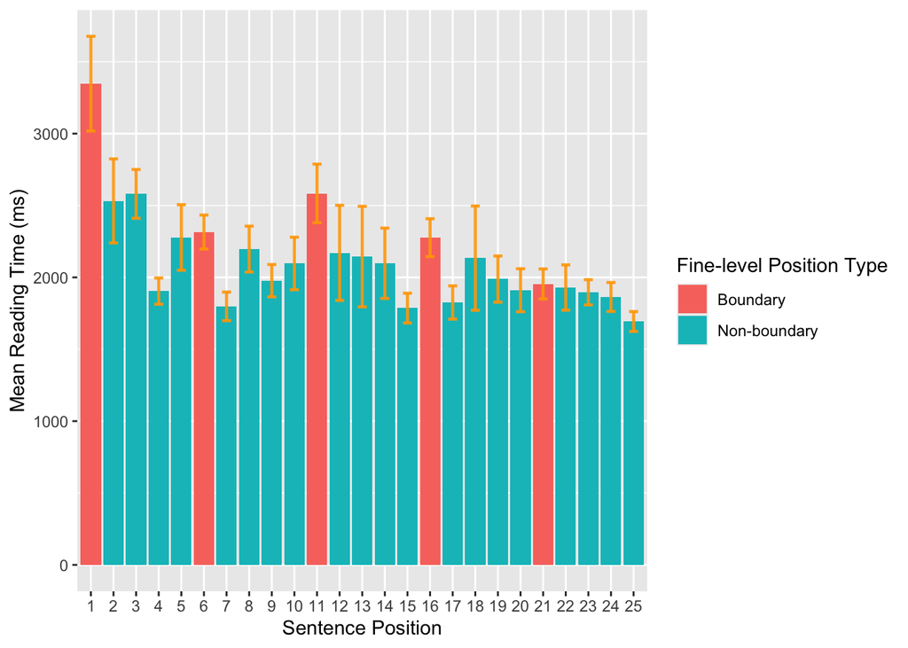

```r
encoding_rt_data_byLocSumm$sentence_index_f <- as.factor(encoding_rt_data_byLocSumm$sentence_index)

encoding_rt_data_byLocSumm %>%
  ggplot(aes(x = sentence_index_f, y = meanRT, fill = fine_loc_type)) +
    geom_bar(stat = "identity") +
    geom_errorbar(aes(x = sentence_index, ymin = meanRT - semRT, ymax = meanRT + semRT), width=0.4, colour="orange", alpha=0.9, size = 0.8) +
  labs(x = "Sentence Position", y = "Mean Reading Time (ms)", fill = "Fine-level Position Type")
```

# 3. Data Analysis of Recency Judgment Accuracy

Hypothesis: Semantic knowledge facilitates temporal order memory. Whether the presence of event boundary impairs or facilitates temporal order memory depends on whether semantic facilitation is on coarse-level events or on fine-level events. (Interaction between narrative_type and pair_type)

- When there is semantic knowledge that helps people infer the temporal order between coarse-level events, temporal order memory of across-event pairs (CS_across pairs) will be better than when there is no semantic knowledge facilitation (FS_across and CS_within pairs).
- Similarly, when there is semantic knowledge facilitation among fine-level events, temporal order memory of within-event pairs (FS_within pairs) will be better than when there is no semantic knowledge facilitation (CS_within and FS_across pairs).
  - Model: Mixed Effects Logistic Regression Model
  - Outcome variable: Temporal Order Memory Accuracy (0/1)
  - Predictors: stimuli_type (CS narrative vs. FS narrative) * pair_type (across-event vs. within-event)
  - Random Effects: run_id (subject) + each_pair (different test pairs)

```r
mean(TOM_data$TOM_result)
```

```
## [1] 0.8568702
```

```r
sd(TOM_data$TOM_result)
```

```
## [1] 0.3502608
```

```r
std.error(TOM_data$TOM_result)
```

```
## [1] 0.006246695
```

```r
# as.factor() certain trials
TOM_data <- mutate(TOM_data, run_id = as.factor(run_id), TOM_result = as.factor(TOM_result))
TOM_data_new <- TOM_data
```

```r
contrasts(TOM_data_new$pair_type) <- contr.sum(2)
contrasts(TOM_data_new$stimuli_type) <- contr.sum(2)
contrasts(TOM_data_new$pair_type)
```

```
##        [,1]
## across    1
## within   -1
```

```r
contrasts(TOM_data_new$stimuli_type)
```

```
##    [,1]
## CS    1
## FS   -1
```

```r
# Model 1: Random slope of stimuli_type * pair_type by subject, and random intercept of each_pair
TOM_accuracy_maximal_model <- glmer(TOM_result ~ stimuli_type * pair_type + (stimuli_type * pair_type |run_id) + (1|each_pair), data = TOM_data_new, family = binomial, control = cl1)

# Model 2: Random slopes of stimuli_type by subject, and random intercept of each_pair
TOM_accuracy_SlopeStimuliType_model <- glmer(TOM_result ~ stimuli_type * pair_type + (stimuli_type |run_id) + (1|each_pair), data = TOM_data_new, family = binomial, control = cl1)

# Model 3: Random slopes of pair_type by subject, and random intercept of each_pair
TOM_accuracy_SlopePairType_model <- glmer(TOM_result ~ stimuli_type * pair_type + (pair_type |run_id) + (1|each_pair), data = TOM_data_new, family = binomial, control = cl1)

# Model 4: Random intercepts of subject and each_pair
TOM_accuracy_Intercept_model <- glmer(TOM_result ~ stimuli_type * pair_type + (1|run_id) + (1|each_pair), data = TOM_data_new, family = binomial)

# Model Comparison favors Model 4 (Random Intercepts of Subject and Test Pair)
anova(TOM_accuracy_Intercept_model, TOM_accuracy_SlopePairType_model, TOM_accuracy_SlopeStimuliType_model, TOM_accuracy_maximal_model)
```

|  | npar | AIC | BIC | logLik | deviance | Chisq | Df | Pr(>Chisq) |
| --- | --- | --- | --- | --- | --- | --- | --- | --- |
| TOM_accuracy_Intercept_model | 6 | 2318.488 | 2354.807 | -1153.244 | 2306.488 | NA | NA | NA |
| TOM_accuracy_SlopePairType_model | 8 | 2319.623 | 2368.049 | -1151.811 | 2303.623 | 2.865061 | 2 | 0.23870411 |
| TOM_accuracy_SlopeStimuliType_model | 8 | 2320.124 | 2368.550 | -1152.062 | 2304.124 | 0.000000 | 0 | NA |
| TOM_accuracy_maximal_model | 15 | 2321.253 | 2412.052 | -1145.627 | 2291.253 | 12.870321 | 7 | 0.07533173 |

```r
# Select Model 4 as the final model
TOM_accuracy_model <- TOM_accuracy_Intercept_model
summ(TOM_accuracy_model, digits = getOption("jtools-digits", 4))
```

```
## MODEL INFO:
## Observations: 3144
## Dependent Variable: TOM_result
## Type: Mixed effects generalized linear regression
## Error Distribution: binomial
## Link function: logit
##
## MODEL FIT:
## AIC = 2318.4880, BIC = 2354.8075
## Pseudo-R² (fixed effects) = 0.0868
## Pseudo-R² (total) = 0.3136
##
## FIXED EFFECTS:
## -------------------------------------------------------------------
##                                    Est.     S.E.    z val.        p
## ------------------------------ -------- -------- --------- --------
## (Intercept)                      2.2442   0.1588   14.1327   0.0000
## stimuli_type1                    0.0476   0.1052    0.4523   0.6511
## pair_type1                       0.0598   0.1053    0.5680   0.5700
## stimuli_type1:pair_type1         0.6403   0.1061    6.0363   0.0000
## -------------------------------------------------------------------
##
## RANDOM EFFECTS:
## -------------------------------------
##    Group      Parameter    Std. Dev.
## ----------- ------------- -----------
##  each_pair   (Intercept)    0.7635
##   run_id     (Intercept)    0.7101
## -------------------------------------
##
## Grouping variables:
## -------------------------------
##    Group     # groups    ICC
## ----------- ---------- --------
##  each_pair      80      0.1332
##   run_id        40      0.1152
## -------------------------------
```

```r
Anova(TOM_accuracy_model, type = "III")
```

|  | Chisq | Df | Pr(>Chisq) |
| --- | --- | --- | --- |
| (Intercept) | 199.7335752 | 1 | 0.000000000000000000000000000000000000000000002387657 |
| stimuli_type | 0.2045690 | 1 | 0.651057865408014135866210381209384649991989135742188 |
| pair_type | 0.3226012 | 1 | 0.570048611855566433881392640614649280905723571777344 |
| stimuli_type:pair_type | 36.4368485 | 1 | 0.000000001576935757671134887638570663001905125533142 |

```r
emmean_TOM_summ <- emmeans(TOM_accuracy_model, specs = ~ stimuli_type * pair_type)
summary(emmean_TOM_summ, type = "response")
```

|  | stimuli_type | pair_type | prob | SE | df | asymp.LCL | asymp.UCL |
| --- | --- | --- | --- | --- | --- | --- | --- |
| 1 | CS | across | 0.9522077 | 0.01166314 | Inf | 0.9234100 | 0.9705232 |
| 2 | FS | across | 0.8342581 | 0.03154242 | Inf | 0.7629652 | 0.8872763 |
| 3 | CS | within | 0.8308580 | 0.03200195 | Inf | 0.7586698 | 0.8847336 |
| 4 | FS | within | 0.9414267 | 0.01405207 | Inf | 0.9070096 | 0.9636166 |

```r
# Set up comparisons
CS_across = c(1,0,0,0)
FS_across = c(0,1,0,0)
CS_within = c(0,0,1,0)
FS_within = c(0,0,0,1)
```

```r
# Planned Contrast - Interaction between stimuli_type and pair_type
contrast(emmean_TOM_summ, method = list("FS_within - CS_within" = FS_within - CS_within,
                                         "FS_within - FS_across" = FS_within - FS_across,
                                         "CS_across - FS_across" = CS_across - FS_across,
                                         "CS_across - CS_within" = CS_across - CS_within),
         adjust = "none")
```

```
##  contrast              estimate    SE  df z.ratio p.value
##  FS_within - CS_within     1.19 0.298 Inf   3.983  0.0001
##  FS_within - FS_across     1.16 0.298 Inf   3.894  0.0001
##  CS_across - FS_across     1.38 0.300 Inf   4.584  <.0001
##  CS_across - CS_within     1.40 0.300 Inf   4.672  <.0001
##
## Results are given on the log odds ratio (not the response) scale.
```

```r
TOM_accuracy_pairwise <- emmeans(TOM_accuracy_model, pairwise ~ stimuli_type * pair_type)
TOM_accuracy_pairwise
```

```
## $emmeans
##  stimuli_type pair_type emmean    SE  df asymp.LCL asymp.UCL
##  CS           across      2.99 0.256 Inf      2.49      3.49
##  FS           across      1.62 0.228 Inf      1.17      2.06
##  CS           within      1.59 0.228 Inf      1.15      2.04
##  FS           within      2.78 0.255 Inf      2.28      3.28
##
## Results are given on the logit (not the response) scale.
## Confidence level used: 0.95
##
## $contrasts
##  contrast              estimate    SE  df z.ratio p.value
##  CS across - FS across   1.3758 0.300 Inf   4.584  <.0001
##  CS across - CS within   1.4002 0.300 Inf   4.672  <.0001
##  CS across - FS within   0.2148 0.316 Inf   0.679  0.9052
##  FS across - CS within   0.0244 0.278 Inf   0.088  0.9998
##  FS across - FS within  -1.1610 0.298 Inf  -3.894  0.0006
##  CS within - FS within  -1.1854 0.298 Inf  -3.983  0.0004
##
## Results are given on the log odds ratio (not the response) scale.
## P value adjustment: tukey method for comparing a family of 4 estimates
```

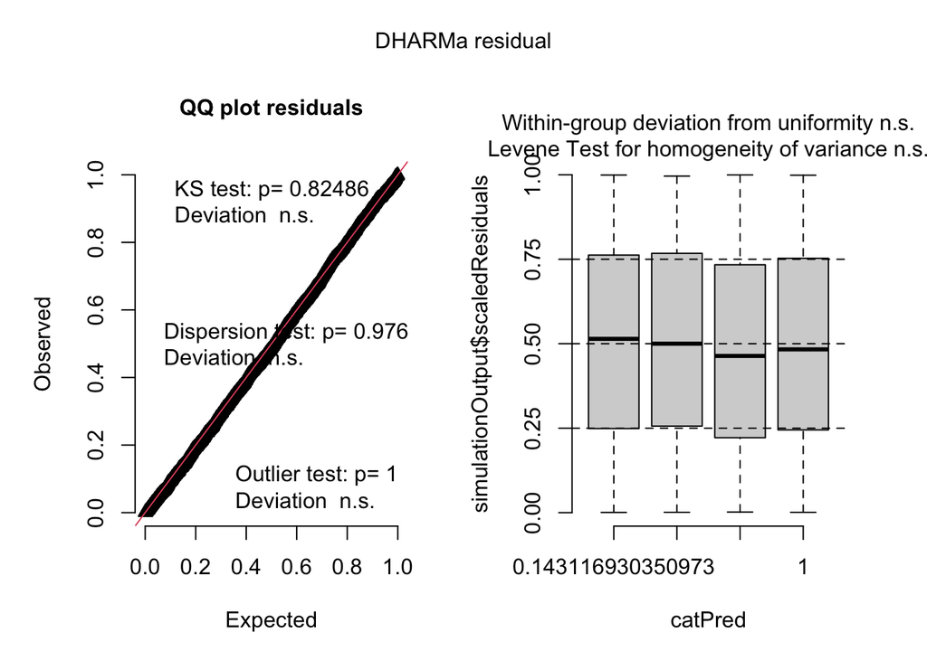

```r
# Check model residuals and assumptions
simulationOutput_TOM <- simulateResiduals(fittedModel = TOM_accuracy_model, plot = F)
plot(simulationOutput_TOM)
```

```r
check_collinearity(TOM_accuracy_model) # Low Multicollinearity
```

| Term | VIF | VIF_CI_low | VIF_CI_high | SE_factor | Tolerance | Tolerance_CI_low | Tolerance_CI_high |
| --- | --- | --- | --- | --- | --- | --- | --- |
| stimuli_type | 1.017172 | 1.002101 | 1.140385 | 1.008550 | 0.9831175 | 0.8768971 | 0.9979038 |
| pair_type | 1.017128 | 1.002084 | 1.140758 | 1.008528 | 0.9831602 | 0.8766099 | 0.9979201 |
| stimuli_type:pair_type | 1.000087 | 1.000000 | Inf | 1.000044 | 0.9999128 | 0.0000000 | 1.0000000 |

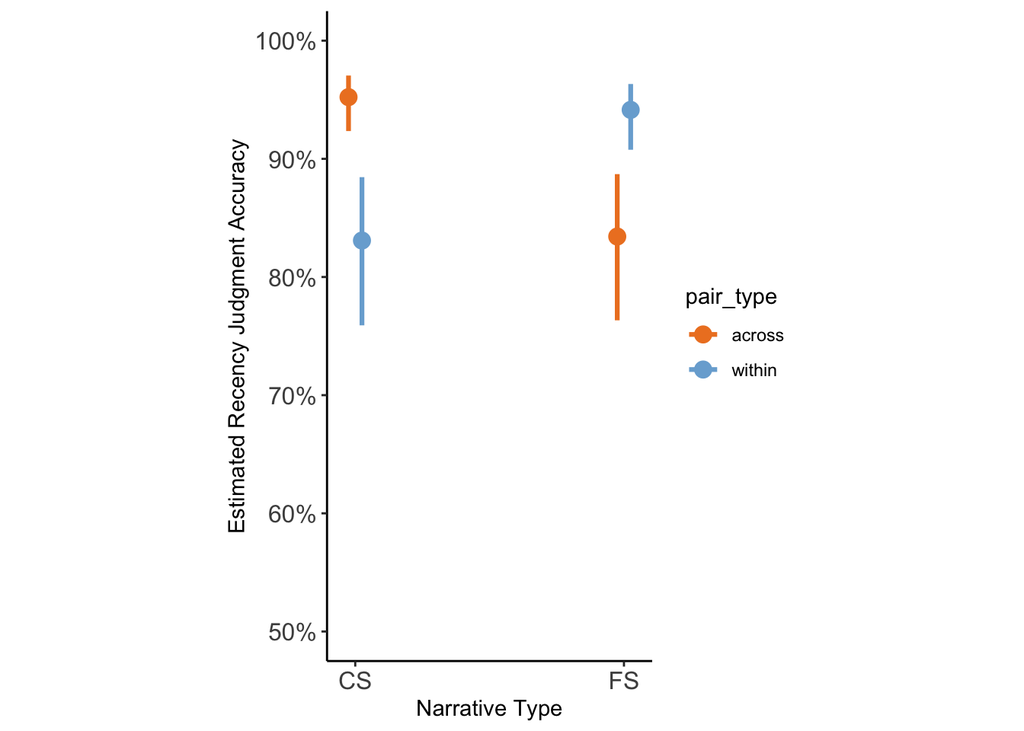

```r
# Plot contrasts - interaction between narrative_type and pair_type
plot_model(TOM_accuracy_model, type = "int", c("pair_type", "stimuli_type"), colors = c("#EE8227", "#79ADD6"), dot.size = 3.5, line.size = 1.1, axis.labels = c("CS Narrative", "FS Narrative")) +
  scale_y_continuous(limits = c(0.5, 1), breaks = c(0.5, 0.6, 0.7, 0.8, 0.9, 1), labels = scales::percent) + theme_classic() +
  theme(aspect.ratio = 2, axis.text = element_text(size = 12)) +
  #aes(color=group) +
  #font_size(axis_title.x = 13, axis_title.y = 13,labels.x = 14, labels.y = 14) +
  labs(x = "Narrative Type", y = "Estimated Recency Judgment Accuracy", title = NULL, size = 2)
```

# 4. Data Analysis of Recency Judgment Confidence

Hypothesis: When there is no facilitation of semantic knowledge, the existence of coarse-level event information may increase people’s confidence in making temporal order judgments - Temporal order memory confidence for FS_across pairs will be higher than CS_within pairs, regardless of the actual accuracy of the judgment.

```r
mean(TOM_Conf_data$TOM_Conf)
```

```
## [1] 76.52979
```

```r
sd(TOM_Conf_data$TOM_Conf)
```

```
## [1] 28.16147
```

```r
std.error(TOM_Conf_data$TOM_Conf)
```

```
## [1] 0.5053874
```

```r
TOM_Conf_data %>% group_by(stimuli_type, pair_type) %>% summarize(meanTOM_Conf = mean(TOM_Conf))
```

| stimuli_type | pair_type | meanTOM_Conf |
| --- | --- | --- |
| CS | across | 80.70437 |
| CS | within | 62.77763 |
| FS | across | 77.13299 |
| FS | within | 85.46675 |

```r
# Dummy Coding event_pair_type:
# FS_across as the reference group. Three Dummy Variables: eventPair_FSw, eventPair_FSa, eventPair_CSw.
# We are interested in the comparison between FS_across (reference group) and CS_within (eventPair_CSw = 1)
TOM_Conf_data$event_pair_type <- as.character(TOM_Conf_data$event_pair_type)
TOM_Conf_data$eventPair_FSw <- ifelse(TOM_Conf_data$event_pair_type == "FS_within", 1, 0)
TOM_Conf_data$eventPair_CSa <- ifelse(TOM_Conf_data$event_pair_type == "CS_across", 1, 0)
TOM_Conf_data$eventPair_CSw <- ifelse(TOM_Conf_data$event_pair_type == "CS_within", 1, 0)

# Factorization
TOM_Conf_data$eventPair_FSw <- as.factor(TOM_Conf_data$eventPair_FSw)
TOM_Conf_data$eventPair_CSa <- as.factor(TOM_Conf_data$eventPair_CSa)
TOM_Conf_data$eventPair_CSw <- as.factor(TOM_Conf_data$eventPair_CSw)

# Dummy Coding TOM_Conf_Group: Low Confidence = 0, High Confidence = 1
TOM_Conf_data <- TOM_Conf_data %>% mutate(TOM_ConfGroup_dumm = dplyr::recode(TOM_ConfGroup,
                                             "Low Confidence" = 0,
                                             "High Confidence" = 1))
TOM_Conf_data$TOM_ConfGroup_dumm <- as.factor(TOM_Conf_data$TOM_ConfGroup_dumm)
```

```r
TOM_Conf_data_new <- TOM_Conf_data
TOM_Conf_data_new$TOM_result <- as.factor(TOM_Conf_data_new$TOM_result)
TOM_Conf_data_new$TOM_result <- relevel(TOM_Conf_data_new$TOM_result, ref = "1")
contrasts(TOM_Conf_data_new$TOM_result) <- contr.sum(2)
```

```r
# Contrast coding for TOM_result: incorrect = -1, correct = 1
contrasts(TOM_Conf_data_new$TOM_result)
```

```
##   [,1]
## 1    1
## 0   -1
```

```r
contrasts(TOM_Conf_data_new$eventPair_CSw)
```

```
##   1
## 0 0
## 1 1
```

```r
contrasts(TOM_Conf_data_new$eventPair_CSa)
```

```
##   1
## 0 0
## 1 1
```

```r
contrasts(TOM_Conf_data_new$eventPair_FSw)
```

```
##   1
## 0 0
## 1 1
```

```r
# Model 1: Random Slope of TOM_result by subject, and random intercept of each_pair
TOM_Conf_SlopeTOMResult_model <- glmer(TOM_ConfGroup_dumm ~ TOM_result + eventPair_CSw + eventPair_CSa + eventPair_FSw + (TOM_result|run_id) + (1|each_pair), data = TOM_Conf_data_new, family = binomial, control = cl1)

# Model 2: Random Slope of pair_type by subject, and random intercept of each_pair
TOM_Conf_SlopePairType_model <- glmer(TOM_ConfGroup_dumm ~ TOM_result + eventPair_CSw + eventPair_CSa + eventPair_FSw + ((eventPair_CSw + eventPair_CSa + eventPair_FSw)|run_id) + (1|each_pair), data = TOM_Conf_data_new, family = binomial, control = cl1)

# Model 3: Random Intercepts of subject and each_pair
TOM_Conf_Intercept_model <- glmer(TOM_ConfGroup_dumm ~ TOM_result + eventPair_CSw + eventPair_CSa + eventPair_FSw + (1|run_id) + (1|each_pair), data = TOM_Conf_data_new, family = binomial)

# Model Comparison favors Model 2: Random Slope of pair_type by subject, and random intercept of each_pair
anova(TOM_Conf_Intercept_model, TOM_Conf_SlopeTOMResult_model, TOM_Conf_SlopePairType_model)
```

|  | npar | AIC | BIC | logLik | deviance | Chisq | Df | Pr(>Chisq) |
| --- | --- | --- | --- | --- | --- | --- | --- | --- |
| TOM_Conf_Intercept_model | 7 | 2766.308 | 2808.593 | -1376.154 | 2752.308 | NA | NA | NA |
| TOM_Conf_SlopeTOMResult_model | 9 | 2765.501 | 2819.868 | -1373.750 | 2747.501 | 4.806791 | 2 | 0.090410427 |
| TOM_Conf_SlopePairType_model | 16 | 2759.920 | 2856.572 | -1363.960 | 2727.920 | 19.581083 | 7 | 0.006549292 |

```r
# Select Model 2
TOM_Conf_model <- TOM_Conf_SlopePairType_model
summ(TOM_Conf_model, digits = getOption("jtools-digits", 4))
```

```
## MODEL INFO:
## Observations: 3105
## Dependent Variable: TOM_ConfGroup_dumm
## Type: Mixed effects generalized linear regression
## Error Distribution: binomial
## Link function: logit
##
## MODEL FIT:
## AIC = 2759.9199, BIC = 2856.5722
## Pseudo-R² (fixed effects) = 0.1168
## Pseudo-R² (total) = 0.6734
##
## FIXED EFFECTS:
## ----------------------------------------------------------
##                           Est.     S.E.    z val.        p
## -------------------- --------- -------- --------- --------
## (Intercept)            -0.9529   0.4071   -2.3404   0.0193
## TOM_result1             0.7782   0.0910    8.5505   0.0000
## eventPair_CSw1         -1.2403   0.3449   -3.5961   0.0003
## eventPair_CSa1          0.3404   0.3557    0.9569   0.3386
## eventPair_FSw1          1.1694   0.3270    3.5763   0.0003
## ----------------------------------------------------------
##
## RANDOM EFFECTS:
## ----------------------------------------
##    Group       Parameter      Std. Dev.
## ----------- ---------------- -----------
##  each_pair    (Intercept)      0.8992
##   run_id      (Intercept)      2.0986
##   run_id     eventPair_CSw1    0.7629
##   run_id     eventPair_CSa1    0.9626
##   run_id     eventPair_FSw1    0.3932
## ----------------------------------------
##
## Grouping variables:
## -------------------------------
##    Group     # groups    ICC
## ----------- ---------- --------
##  each_pair      80      0.0951
##   run_id        40      0.5180
## -------------------------------
```

```r
Anova(TOM_Conf_model, type = "III")
```

|  | Chisq | Df | Pr(>Chisq) |
| --- | --- | --- | --- |
| (Intercept) | 5.4774075 | 1 | 0.01926380839755422250126 |
| TOM_result | 73.1114662 | 1 | 0.00000000000000001225306 |
| eventPair_CSw | 12.9322653 | 1 | 0.00032296670570583610503 |
| eventPair_CSa | 0.9156616 | 1 | 0.33861668187026244813964 |
| eventPair_FSw | 12.7897183 | 1 | 0.00034852959307961567468 |

```r
# Contrasts for CSw and FSa
emmeans(TOM_Conf_model, pairwise ~ eventPair_CSw)
```

```
## $emmeans
##  eventPair_CSw emmean    SE  df asymp.LCL asymp.UCL
##  0             -0.198 0.392 Inf    -0.967     0.571
##  1             -1.438 0.535 Inf    -2.488    -0.389
##
## Results are averaged over the levels of: TOM_result, eventPair_CSa, eventPair_FSw
## Results are given on the logit (not the response) scale.
## Confidence level used: 0.95
##
## $contrasts
##  contrast                        estimate    SE  df z.ratio p.value
##  eventPair_CSw0 - eventPair_CSw1     1.24 0.345 Inf   3.596  0.0003
##
## Results are averaged over the levels of: TOM_result, eventPair_CSa, eventPair_FSw
## Results are given on the log odds ratio (not the response) scale.
```

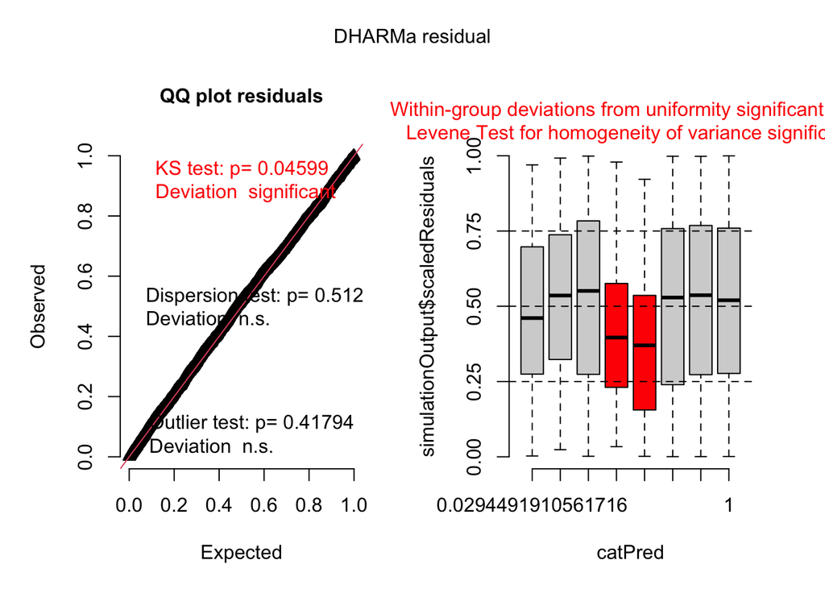

```r
# Check residual distribution and model assumptions
simulationOutput_TOM_Conf <- simulateResiduals(fittedModel = TOM_Conf_model, plot = F)
plot(simulationOutput_TOM_Conf)
```

```r
check_collinearity(TOM_Conf_model) # Low Multicollinearity
```

| Term | VIF | VIF_CI_low | VIF_CI_high | SE_factor | Tolerance | Tolerance_CI_low | Tolerance_CI_high |
| --- | --- | --- | --- | --- | --- | --- | --- |
| TOM_result | 1.002564 | 1.000000 | 2410.572921 | 1.001281 | 0.9974422 | 0.0004148391 | 1.0000000 |
| eventPair_CSw | 1.474734 | 1.411029 | 1.548312 | 1.214386 | 0.6780886 | 0.6458648371 | 0.7087026 |
| eventPair_CSa | 1.566614 | 1.496495 | 1.646636 | 1.251645 | 0.6383193 | 0.6072989028 | 0.6682280 |
| eventPair_FSw | 1.480450 | 1.416344 | 1.554426 | 1.216737 | 0.6754704 | 0.6433243176 | 0.7060431 |

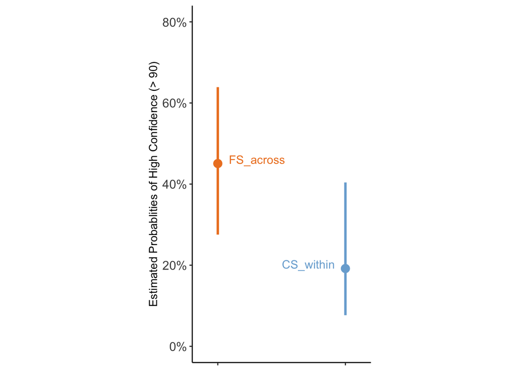

```r
# Plot the model
p <- plot_model(TOM_Conf_model,
               type = "emm",
               terms = c("eventPair_CSw"),
               dot.size = 3.5,
               line.size = 1.1)

p$data$group <- as.factor(p$data$x)

# Add a new layer with explicit color mapping
new_p <- ggplot(p$data, aes(x = x, y = predicted)) +
  geom_point(aes(color = group), size = 3.5) +
  geom_errorbar(aes(ymin = conf.low, ymax = conf.high, color = group),
                width = 0, size = 1.1) +
  scale_color_manual(values = c("#EE8227","#79ADD6"), guide = "none") +
  scale_y_continuous(limits = c(0, 0.8),
                    breaks = c(0, 0.2, 0.4, 0.6, 0.8),
                    labels = scales::percent) +
  scale_x_continuous(breaks = c(0, 1),
                   expand = expansion(mult = 0.2)) +
  geom_text(aes(label = c("FS_across", "CS_within"),
                x = x, y = predicted, color = group,
            hjust = ifelse(x == min(x), -0.2, 1.2)),
            vjust = 0,   # Adjust vertical position
            size = 4) +   # Adjust text size
  theme_classic() +
  theme(aspect.ratio = 2, axis.text = element_text(size = 12), axis.text.x = element_blank(), plot.title = element_text(margin = margin(b = 30))) +
 # scale_x_continuous(breaks = c(0,1), labels = c("FS_across", "CS_within")) +
  labs(x = NULL, y = "Estimated Probablities of High Confidence (> 90)")
new_p
```

# 5. Data Analysis of Temporal Distance Rating

Hypothesis: Temporal distance is rated as farther if two fine-level events span across event boundary.

- Model: Mixed Effects Linear Regression Model
- Outcome variable: Temporal Distance Rating (1-10)
- Predictor: stimuli_type (CS narrative vs. FS narrative) * pair_type (across-event vs. within-event)
- Random Effects: run_id (subject) + each_pair (different test pairs)

```r
# as.factor() certain columns
TD_data <- mutate(TD_data, run_id = as.factor(run_id))
```

```r
mean(TD_data$TD)
```

```
## [1] 3.61274
```

```r
sd(TD_data$TD)
```

```
## [1] 1.996562
```

```r
std.error(TD_data$TD)
```

```
## [1] 0.03545559
```

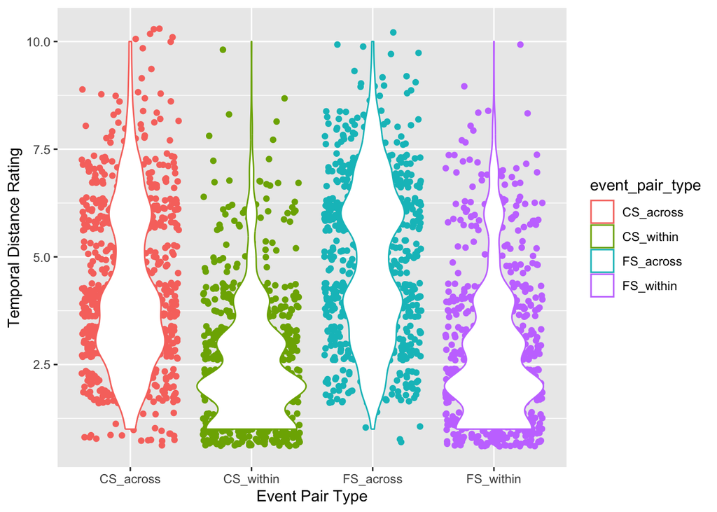

```r
summ_TD_aov_graph <- TD_data %>% group_by(event_pair_type)
summ_TD_aov_graph %>% ggplot(aes(x = event_pair_type, y = TD, color = event_pair_type)) + geom_jitter() + geom_violin() + labs(x = "Event Pair Type", y = "Temporal Distance Rating")
```

```r
TD_data_new <- TD_data
contrasts(TD_data_new$stimuli_type) <- contr.sum(2)
contrasts(TD_data_new$pair_type) <- contr.sum(2)

contrasts(TD_data_new$stimuli_type)
```

```
##    [,1]
## CS    1
## FS   -1
```

```r
contrasts(TD_data_new$pair_type)
```

```
##        [,1]
## across    1
## within   -1
```

```r
# Model 1: Random Slope of stimuli_type * pair_type, and random intercept of each_pair
TempDistance_Maximal_model <- lmer(TD ~ stimuli_type * pair_type + (stimuli_type * pair_type |run_id) + (1| each_pair), data = TD_data_new, control = cl_a)

# Model 2: Random Slope of stimuli_type by subject, and random intercept of each_pair
TempDistance_SlopeStimuliType_model <- lmer(TD ~ stimuli_type * pair_type + (stimuli_type |run_id) + (1| each_pair), data = TD_data_new)

# Model 3: Random Slope of pair_type by subject, and random intercept of each_pair
TempDistance_SlopePairType_model <- lmer(TD ~ stimuli_type * pair_type + (pair_type |run_id) + (1| each_pair), data = TD_data_new)

# Model 4: Random Intercepts of subject and each_pair
TempDistance_Intercept_model <- lmer(TD ~ stimuli_type * pair_type + (1 |run_id) + (1| each_pair), data = TD_data_new)

# Model Comparison favors Model 1: Random Slope of stimuli_type * pair_type, and random intercept of each_pair
anova(TempDistance_Intercept_model, TempDistance_SlopePairType_model, TempDistance_SlopeStimuliType_model, TempDistance_Maximal_model)
```

```
## refitting model(s) with ML (instead of REML)
```

|  | npar | AIC | BIC | logLik | deviance | Chisq | Df | Pr(>Chisq) |
| --- | --- | --- | --- | --- | --- | --- | --- | --- |
| TempDistance_Intercept_model | 7 | 11383.71 | 11426.14 | -5684.853 | 11369.71 | NA | NA | NA |
| TempDistance_SlopePairType_model | 9 | 11308.41 | 11362.97 | -5645.207 | 11290.41 | 79.29147 | 2 | 0.000000000000000006054463 |
| TempDistance_SlopeStimuliType_model | 9 | 11379.62 | 11434.18 | -5680.812 | 11361.62 | 0.00000 | 0 | NA |
| TempDistance_Maximal_model | 16 | 11306.56 | 11403.55 | -5637.281 | 11274.56 | 87.06113 | 7 | 0.000000000000000495904935 |

```r
TempDistance_model <- TempDistance_Maximal_model
summ(TempDistance_model, digits = getOption("jtools-digits", 4))
```

```
## MODEL INFO:
## Observations: 3171
## Dependent Variable: TD
## Type: Mixed effects linear regression
##
## MODEL FIT:
## AIC = 11319.2002, BIC = 11416.1890
## Pseudo-R² (fixed effects) = 0.2592
## Pseudo-R² (total) = 0.5481
##
## FIXED EFFECTS:
## ------------------------------------------------------------------------------
##                                     Est.     S.E.    t val.      d.f.        p
## ------------------------------ --------- -------- --------- --------- --------
## (Intercept)                       3.6154   0.1537   23.5202   50.8776   0.0000
## stimuli_type1                    -0.2408   0.0648   -3.7136   84.2891   0.0004
## pair_type1                        0.9887   0.0761   12.9876   92.1884   0.0000
## stimuli_type1:pair_type1         -0.0863   0.0628   -1.3755   79.0849   0.1729
## ------------------------------------------------------------------------------
##
## p values calculated using Satterthwaite d.f.
##
## RANDOM EFFECTS:
## --------------------------------------------------
##    Group            Parameter           Std. Dev.
## ----------- -------------------------- -----------
##  each_pair         (Intercept)           0.4986
##   run_id           (Intercept)           0.8932
##   run_id          stimuli_type1          0.1446
##   run_id            pair_type1           0.2908
##   run_id     stimuli_type1:pair_type1    0.1018
##  Residual                                1.3481
## --------------------------------------------------
##
## Grouping variables:
## -------------------------------
##    Group     # groups    ICC
## ----------- ---------- --------
##  each_pair      80      0.0868
##   run_id        40      0.2786
## -------------------------------
```

```r
anova(TempDistance_model, type = "III")
```

|  | Sum Sq | Mean Sq | NumDF | DenDF | F value | Pr(>F) |
| --- | --- | --- | --- | --- | --- | --- |
| stimuli_type | 25.062473 | 25.062473 | 1 | 84.28915 | 13.791150 | 0.0003660399746390681518549981 |
| pair_type | 306.536400 | 306.536400 | 1 | 92.18836 | 168.678058 | 0.0000000000000000000001541479 |
| stimuli_type:pair_type | 3.438147 | 3.438147 | 1 | 79.08485 | 1.891912 | 0.1728699817157866858163828283 |

```r
emmean_TD_summ <- emmeans(TempDistance_model, specs = ~ stimuli_type * pair_type)
```

```
## Note: D.f. calculations have been disabled because the number of observations exceeds 3000.
## To enable adjustments, add the argument 'pbkrtest.limit = 3171' (or larger)
## [or, globally, 'set emm_options(pbkrtest.limit = 3171)' or larger];
## but be warned that this may result in large computation time and memory use.
```

```
## Note: D.f. calculations have been disabled because the number of observations exceeds 3000.
## To enable adjustments, add the argument 'lmerTest.limit = 3171' (or larger)
## [or, globally, 'set emm_options(lmerTest.limit = 3171)' or larger];
## but be warned that this may result in large computation time and memory use.
```

```r
summary(emmean_TD_summ, type = "response")
```

|  | stimuli_type | pair_type | emmean | SE | df | asymp.LCL | asymp.UCL |
| --- | --- | --- | --- | --- | --- | --- | --- |
| 1 | CS | across | 4.276934 | 0.2015122 | Inf | 3.881978 | 4.671891 |
| 2 | FS | across | 4.931160 | 0.2043099 | Inf | 4.530720 | 5.331600 |
| 3 | CS | within | 2.472215 | 0.1814013 | Inf | 2.116675 | 2.827755 |
| 4 | FS | within | 2.781106 | 0.1871061 | Inf | 2.414385 | 3.147828 |

```r
# Planned Contrast
contrast(emmean_TD_summ, method = list("CS_across - CS_within" = CS_across - CS_within,
                                         "CS_across - FS_within" = CS_across - FS_within,
                                         "FS_across - CS_within" = FS_across - CS_within,
                                         "FS_across - FS_within" = FS_across - FS_within),
         adjust = "none")
```

```
##  contrast              estimate    SE  df z.ratio p.value
##  CS_across - CS_within     1.80 0.194 Inf   9.311  <.0001
##  CS_across - FS_within     1.50 0.196 Inf   7.635  <.0001
##  FS_across - CS_within     2.46 0.204 Inf  12.055  <.0001
##  FS_across - FS_within     2.15 0.201 Inf  10.709  <.0001
##
## Degrees-of-freedom method: asymptotic
```

```r
# Planned Contrast
TD_pairwise <- emmeans(TempDistance_model, pairwise ~ stimuli_type * pair_type)
TD_pairwise
```

```
## $emmeans
##  stimuli_type pair_type emmean    SE  df asymp.LCL asymp.UCL
##  CS           across      4.28 0.202 Inf      3.88      4.67
##  FS           across      4.93 0.204 Inf      4.53      5.33
##  CS           within      2.47 0.181 Inf      2.12      2.83
##  FS           within      2.78 0.187 Inf      2.41      3.15
##
## Degrees-of-freedom method: asymptotic
## Confidence level used: 0.95
##
## $contrasts
##  contrast              estimate    SE  df z.ratio p.value
##  CS across - FS across   -0.654 0.185 Inf  -3.531  0.0023
##  CS across - CS within    1.805 0.194 Inf   9.311  <.0001
##  CS across - FS within    1.496 0.196 Inf   7.635  <.0001
##  FS across - CS within    2.459 0.204 Inf  12.055  <.0001
##  FS across - FS within    2.150 0.201 Inf  10.709  <.0001
##  CS within - FS within   -0.309 0.176 Inf  -1.760  0.2931
##
## Degrees-of-freedom method: asymptotic
## P value adjustment: tukey method for comparing a family of 4 estimates
```

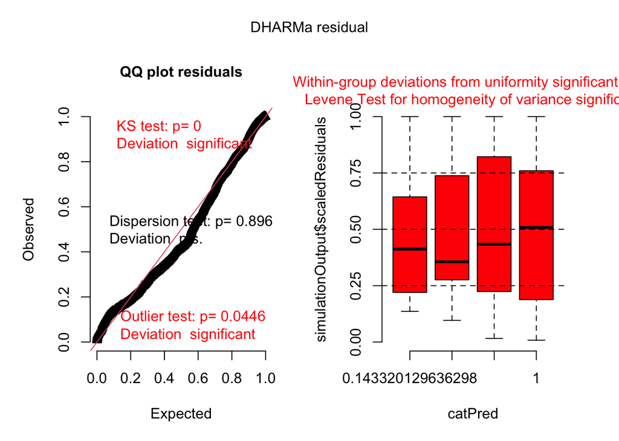

```r
# Check residual distribution and model assumptions
simulationOutput_TD <- simulateResiduals(fittedModel = TempDistance_model, plot = F)
plot(simulationOutput_TD)
```

```r
check_collinearity(TempDistance_model) # Low Multicollinearity
```

| Term | VIF | VIF_CI_low | VIF_CI_high | SE_factor | Tolerance | Tolerance_CI_low | Tolerance_CI_high |
| --- | --- | --- | --- | --- | --- | --- | --- |
| stimuli_type | 1.004444 | 1.000002 | 12.81017 | 1.002220 | 0.9955755 | 0.07806299 | 0.9999983 |
| pair_type | 1.002810 | 1.000000 | 704.13099 | 1.001404 | 0.9971978 | 0.00142019 | 1.0000000 |
| stimuli_type:pair_type | 1.004052 | 1.000001 | 23.93255 | 1.002024 | 0.9959641 | 0.04178409 | 0.9999993 |

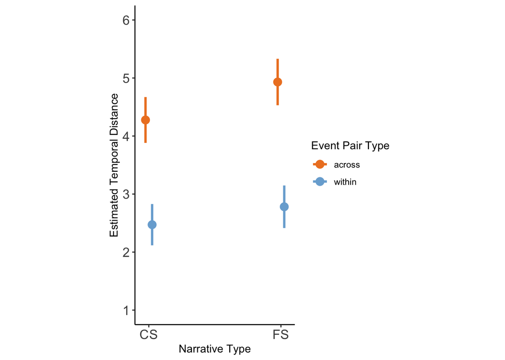

```r
plot_model(TempDistance_model, type = "pred", terms = c("stimuli_type", "pair_type"), legend.title = "Event Pair Type", colors = c("#EE8227", "#79ADD6"), dot.size = 3.5, line.size = 1.1, axis.labels = c("CS Narrative", "FS Narrative")) +
  scale_y_continuous(limits = c(1, 6), breaks = c(1, 2, 3, 4, 5, 6)) +
  theme_classic() +
  theme(aspect.ratio = 2, axis.text = element_text(size = 13)) +
  #aes(color=group) +
  #font_size(axis_title.x = 13, axis_title.y = 13,labels.x = 14, labels.y = 14) +
  labs(title = NULL, x = "Narrative Type", y = "Estimated Temporal Distance", fill = "Fine-level Event Pair Type", size = 8)
```

## Supplemental: Control for time elapsed between two sentences during encoding

```r
### Method: Get time elapsed between two sentences in each pair during encoding
# Define the function (subtraction to get elapsed time for each pair)
calculate_elapsed_time <- function(df, ranges) {

  # Initialize an empty list to store results
  results <- data.frame(
    run_id = numeric(),
    stimuli_name = character(),
    pair_index = numeric(),
    time_elapsed = numeric()
  )

  # Loop over each range and calculate the sum
  for (range in ranges) {
    end_trial <- range[1]
    start_trial <- range[2]
    TD_trial_num <- range[3]

    end_trial_row <- df[df$sentence_index == end_trial, ]
    start_trial_row <- df[df$sentence_index == start_trial, ]

    # Get Elapsed Time for each pair
    diff <- end_trial_row$time_elapsed - start_trial_row$time_elapsed

    new_result_row <- list(run_id = start_trial_row$run_id,
                           stimuli_name = start_trial_row$stimuli_name,
                           pair_index = TD_trial_num,
                           time_elapsed = diff)

    results <- rbind(results, new_result_row)

  }
  return(results)
}

stimuli_list <- unique(encoding_rt_main$stimuli_name)
```

```r
# Define the ranges: elapsed_time - Long (2+3+4+5)
elapsed_time_ranges_long <- list(c(5, 1, 1), c(6, 2, 2), c(10, 6, 3), c(11, 7, 4), c(15, 11, 5), c(16, 12, 6), c(20, 16, 7), c(21, 17, 8))

# Store elapsed time result in a dataframe
TD_elapsed_time_df_long <- data.frame(
  run_id = numeric(),
  stimuli_name = character(),
  pair_index = numeric(),
  time_elapsed = numeric()
)
```

```r
# For long range: Run the function for each narrative and store output
for (id in id_list) {
  for (stimuli in stimuli_list) {

    subset_df <- encoding_rt_main %>% subset(run_id == id & stimuli_name == stimuli) %>%
                 dplyr::select('run_id', 'stimuli_name', 'sentence_index', 'time_elapsed')

    each_narrative_df <- calculate_elapsed_time(subset_df, elapsed_time_ranges_long)

    TD_elapsed_time_df_long <- rbind(TD_elapsed_time_df_long, each_narrative_df)
  }
}
```

```r
TD_elapsed_time_df_long <- TD_elapsed_time_df_long %>%
  mutate(person_stimuli_index = paste(run_id, stimuli_name, sep = "_"),
         TD_unique_trial_index = paste(person_stimuli_index, pair_index, sep = "_")) %>%
  rename(time_elapsed_long = time_elapsed)

TD_elapsed_time_df_long_simple <- TD_elapsed_time_df_long %>%
  dplyr::select(TD_unique_trial_index, time_elapsed_long)
```

```r
NEW_TD_data <- TempOrder_data %>%
  mutate(TD_unique_trial_index = paste(run_id, each_pair, sep = "_"))

# Add elapsed time data
NEW_TD_data <- left_join(NEW_TD_data, TD_elapsed_time_df_long_simple, by = "TD_unique_trial_index")

NEW_TD_data <- NEW_TD_data %>% filter(excluded_by_TD_rt == FALSE)
```

```r
# Calculate encoding_rt upper limit: 3SD above mean
TD_elapsed_time_upperLim <- as.numeric(NEW_TD_data %>% summarize(upperLim = mean(time_elapsed_long) + 3 * sd(time_elapsed_long)))
TD_elapsed_time_upperLim
```

```
## [1] 48486.38
```

```r
# Tag all the trials that are excluded by rt < 300 or > 3SD above mean
NEW_TD_data$excluded_by_elapsed_time <- ifelse(NEW_TD_data$time_elapsed_long > TD_elapsed_time_upperLim | NEW_TD_data$time_elapsed_long < 300, yes = TRUE, no = FALSE)

NEW_TD_data_seg <- NEW_TD_data %>% filter(excluded_by_elapsed_time == FALSE)

(nrow(NEW_TD_data) - nrow(NEW_TD_data_seg))/nrow(NEW_TD_data)
```

```
## [1] 0.008199306
```

```r
NEW_TD_data_seg %>% group_by(stimuli_type, pair_type) %>% summarize(mean_time_elapsed_long = mean(time_elapsed_long), sd_time_elapsed_long = sd(time_elapsed_long), ntrial = n())
```

| stimuli_type | pair_type | mean_time_elapsed_long | sd_time_elapsed_long | ntrial |
| --- | --- | --- | --- | --- |
| CS | across | 12098.93 | 5357.830 | 786 |
| CS | within | 12107.73 | 5848.434 | 792 |
| FS | across | 12071.04 | 5842.384 | 782 |
| FS | within | 11656.08 | 5464.186 | 785 |

```r
### Rerun TD Analysis with elapsed time as a covariate
contrasts(NEW_TD_data_seg$stimuli_type) <- contr.sum(2)
contrasts(NEW_TD_data_seg$pair_type) <- contr.sum(2)

contrasts(NEW_TD_data_seg$stimuli_type)
```

```
##    [,1]
## CS    1
## FS   -1
```

```r
contrasts(NEW_TD_data_seg$pair_type)
```

```
##        [,1]
## across    1
## within   -1
```

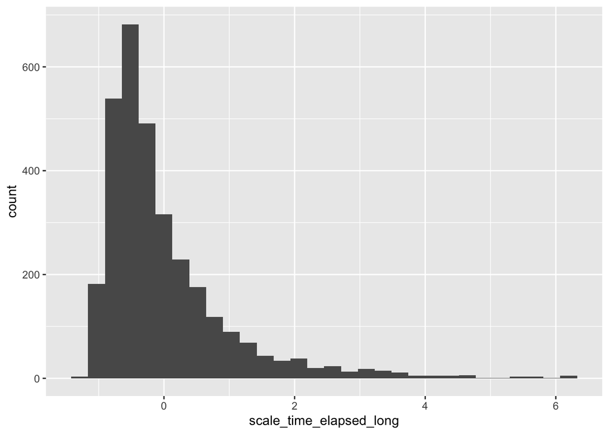

```r
NEW_TD_data_seg$scale_time_elapsed_long <- scale(NEW_TD_data_seg$time_elapsed_long)
NEW_TD_data_seg %>% ggplot(aes(x = scale_time_elapsed_long)) + geom_histogram()
```

```r
NEW_TD_model <- lmer(TD ~ stimuli_type * pair_type + scale_time_elapsed_long + (stimuli_type * pair_type |run_id) + (1| each_pair), data = NEW_TD_data_seg, control = cl_a)
summ(NEW_TD_model, digits = getOption("jtools-digits", 4))
```

```
## MODEL INFO:
## Observations: 3145
## Dependent Variable: TD
## Type: Mixed effects linear regression
##
## MODEL FIT:
## AIC = 11235.9684, BIC = 11338.8791
## Pseudo-R² (fixed effects) = 0.2585
## Pseudo-R² (total) = 0.5481
##
## FIXED EFFECTS:
## --------------------------------------------------------------------------------
##                                     Est.     S.E.    t val.        d.f.        p
## ------------------------------ --------- -------- --------- ----------- --------
## (Intercept)                       3.6130   0.1544   23.3989     50.7348   0.0000
## stimuli_type1                    -0.2368   0.0644   -3.6749     82.7175   0.0004
## pair_type1                        0.9872   0.0759   13.0031     92.3625   0.0000
## scale_time_elapsed_long           0.0425   0.0292    1.4549   2989.3730   0.1458
## stimuli_type1:pair_type1         -0.0843   0.0632   -1.3354     79.4001   0.1856
## --------------------------------------------------------------------------------
##
## p values calculated using Satterthwaite d.f.
##
## RANDOM EFFECTS:
## --------------------------------------------------
##    Group            Parameter           Std. Dev.
## ----------- -------------------------- -----------
##  each_pair         (Intercept)           0.5006
##   run_id           (Intercept)           0.8973
##   run_id          stimuli_type1          0.1325
##   run_id            pair_type1           0.2865
##   run_id     stimuli_type1:pair_type1    0.1051
##  Residual                                1.3489
## --------------------------------------------------
##
## Grouping variables:
## -------------------------------
##    Group     # groups    ICC
## ----------- ---------- --------
##  each_pair      80      0.0871
##   run_id        40      0.2800
## -------------------------------
```

```r
anova(NEW_TD_model, type = "III")
```

|  | Sum Sq | Mean Sq | NumDF | DenDF | F value | Pr(>F) |
| --- | --- | --- | --- | --- | --- | --- |
| stimuli_type | 24.573583 | 24.573583 | 1 | 82.71747 | 13.505119 | 0.0004213165511778092613137670 |
| pair_type | 307.655835 | 307.655835 | 1 | 92.36247 | 169.081101 | 0.0000000000000000000001385767 |
| scale_time_elapsed_long | 3.851503 | 3.851503 | 1 | 2989.37296 | 2.116704 | 0.1458047642929705955960884012 |
| stimuli_type:pair_type | 3.244884 | 3.244884 | 1 | 79.40007 | 1.783319 | 0.1855580486449136257132153105 |

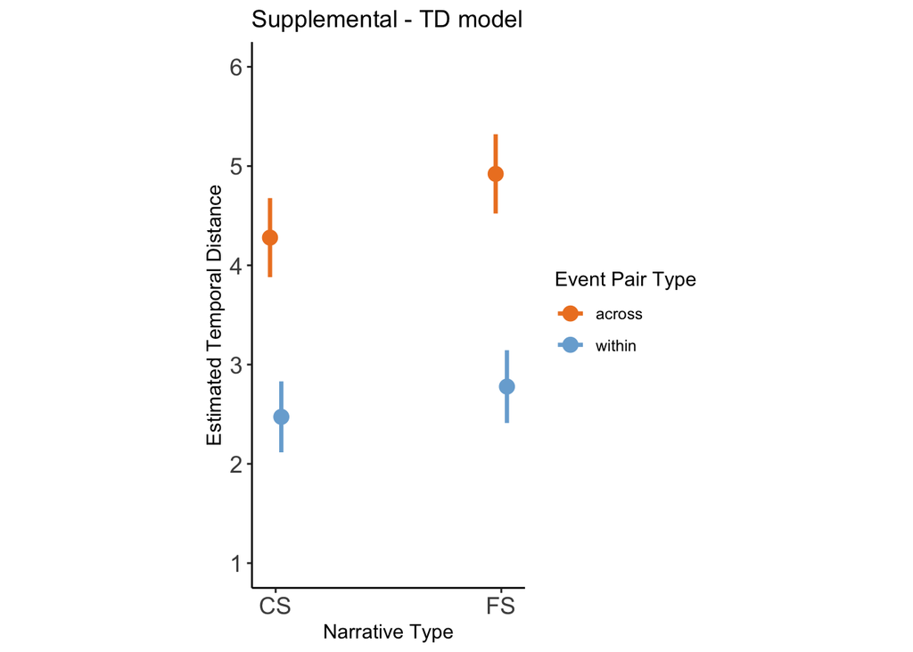

```r
plot_model(NEW_TD_model, type = "pred", terms = c("stimuli_type", "pair_type"), legend.title = "Event Pair Type", colors = c("#EE8227", "#79ADD6"), dot.size = 3.5, line.size = 1.1, axis.labels = c("CS Narrative", "FS Narrative")) +
  scale_y_continuous(limits = c(1, 6), breaks = c(1, 2, 3, 4, 5, 6)) +
  theme_classic() +
  theme(aspect.ratio = 2, axis.text = element_text(size = 13)) +
  #aes(color=group) +
  #font_size(axis_title.x = 13, axis_title.y = 13,labels.x = 14, labels.y = 14) +
  labs(title = "Supplemental - TD model", x = "Narrative Type", y = "Estimated Temporal Distance", fill = "Fine-level Event Pair Type", size = 8)
```

```r
emmean_NEW_TD_summ <- emmeans(NEW_TD_model, specs = ~ stimuli_type * pair_type)
```

```
## Note: D.f. calculations have been disabled because the number of observations exceeds 3000.
## To enable adjustments, add the argument 'pbkrtest.limit = 3145' (or larger)
## [or, globally, 'set emm_options(pbkrtest.limit = 3145)' or larger];
## but be warned that this may result in large computation time and memory use.
```

```
## Note: D.f. calculations have been disabled because the number of observations exceeds 3000.
## To enable adjustments, add the argument 'lmerTest.limit = 3145' (or larger)
## [or, globally, 'set emm_options(lmerTest.limit = 3145)' or larger];
## but be warned that this may result in large computation time and memory use.
```

```r
summary(emmean_NEW_TD_summ, type = "response")
```

|  | stimuli_type | pair_type | emmean | SE | df | asymp.LCL | asymp.UCL |
| --- | --- | --- | --- | --- | --- | --- | --- |
| 1 | CS | across | 4.279111 | 0.2031480 | Inf | 3.880948 | 4.677273 |
| 2 | FS | across | 4.921308 | 0.2037536 | Inf | 4.521958 | 5.320658 |
| 3 | CS | within | 2.473416 | 0.1822872 | Inf | 2.116140 | 2.830693 |
| 4 | FS | within | 2.778283 | 0.1869949 | Inf | 2.411780 | 3.144786 |

```r
# Planned Contrast
contrast(emmean_NEW_TD_summ, method = list("CS_across - CS_within" = CS_across - CS_within,
                                         "CS_across - FS_within" = CS_across - FS_within,
                                         "FS_across - CS_within" = FS_across - CS_within,
                                         "FS_across - FS_within" = FS_across - FS_within),
         adjust = "none")
```

```
##  contrast              estimate    SE  df z.ratio p.value
##  CS_across - CS_within     1.81 0.194 Inf   9.291  <.0001
##  CS_across - FS_within     1.50 0.196 Inf   7.660  <.0001
##  FS_across - CS_within     2.45 0.202 Inf  12.099  <.0001
##  FS_across - FS_within     2.14 0.201 Inf  10.683  <.0001
##
## Degrees-of-freedom method: asymptotic
```

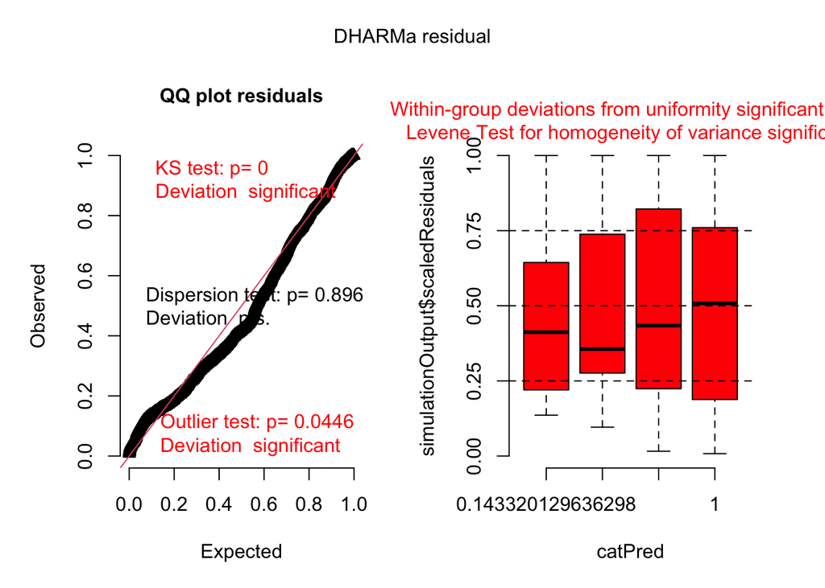

```r
# Check residual distribution and model assumptions
simulationOutput_NEW_TD <- simulateResiduals(fittedModel = TempDistance_model, plot = F)
plot(simulationOutput_TD)
```

```r
check_collinearity(TempDistance_model) # Low Multicollinearity
```

| Term | VIF | VIF_CI_low | VIF_CI_high | SE_factor | Tolerance | Tolerance_CI_low | Tolerance_CI_high |
| --- | --- | --- | --- | --- | --- | --- | --- |
| stimuli_type | 1.004444 | 1.000002 | 12.81017 | 1.002220 | 0.9955755 | 0.07806299 | 0.9999983 |
| pair_type | 1.002810 | 1.000000 | 704.13099 | 1.001404 | 0.9971978 | 0.00142019 | 1.0000000 |
| stimuli_type:pair_type | 1.004052 | 1.000001 | 23.93255 | 1.002024 | 0.9959641 | 0.04178409 | 0.9999993 |